# Báo cáo cuối kỳ Xử lý số liệu thống kê

Nhóm 15

2024-12-18

# Thành viên nhóm:

1. Đậu Quang Anh - 22110014
2. Lâm Gia Bảo - 22110023
3. Trần Duy An - 22110008
4. Lê Thị Hồng Đang - 22110033
5. Trần Quốc Danh - 22110035

# 1. Giới thiệu

Bệnh tiểu đường hiện nay đang trở thành một trong những căn bệnh mãn tính phổ biến và nghiêm trọng nhất trên toàn cầu. Căn bệnh này xảy ra khi cơ thể không thể điều chỉnh hiệu quả mức độ glucose trong máu, dẫn đến những biến chứng nghiêm trọng như bệnh tim mạch, mất thị lực, cắt cụt chi dưới, và bệnh thận. Mặc dù hiện tại chưa có phương pháp chữa khỏi bệnh tiểu đường, nhưng các chiến lược can thiệp như giảm cân, duy trì chế độ ăn uống lành mạnh, tăng cường vận động thể chất và điều trị y tế có thể giúp làm giảm các tác động tiêu cực của bệnh, đặc biệt là khi chẩn đoán sớm và thay đổi lối sống có thể cải thiện hiệu quả điều trị.

Dữ liệu `diabetes_012_health_indicators_BRFSS2015.csv` được thu thập từ khảo sát của 253,680 người dân Hoa Kỳ vào năm 2015, cung cấp một tập hợp các chỉ số sức khỏe và các yếu tố nguy cơ liên quan đến bệnh tiểu đường.

Dữ liệu này bao gồm 22 biến quan sát, bao gồm các biến sau:

- `Diabetes_012`: Tình trạng bệnh tiểu đường (0: không tiểu đường, 1: tiền tiểu đường, 2: tiểu đường).
- `HighBP`: Tình trạng cao huyết áp (0, 1).
  - 0: Không cao huyết áp.
  - 1: Cao huyết áp.
- `HighChol`: Tình trạng cholesterol cao (0, 1).
  - 0: Không cholesterol cao.
  - 1: Cholesterol cao.
- `CholCheck`: Kiểm tra cholesterol trong vòng 5 năm qua (0, 1).
  - 0: Không.
  - 1: Có.
- `BMI`: Chỉ số khối cơ thể (BMI).
- `Smoker`: Người đã hút ít nhất 100 điếu thuốc trong suốt cuộc đời mình? (0, 1), [Lưu ý: 5 gói = 100 điều thuốc].
  - 0: Không.
  - 1: Có.
- `Age`: Tuổi của người tham gia khảo sát.
- `Stroke`: Đã từng được chẩn đoán bị đột quỵ (0, 1).
  - 0: Chưa từng bị đột quỵ.
  - 1: Đã từng bị đột quỵ.
- `HeartDiseaseorAttack`: Đã từng được chẩn đoán mắc bệnh tim mạch vành (CHD) hoặc nhồi máu cơ tim (MI) (0, 1).
  - 0: Chưa từng.
  - 1: Đã từng.
- `PhysActivity`: Có hoạt động thể chất trong vòng 30 ngày, không tính hoạt động liên quan tới công việc? (0, 1).
  - 0: Không.
  - 1: Có.
- `Fruits`: Tiêu thụ trái cây ít nhất 1 lần mỗi ngày? (0, 1).
  - 0: Không.
  - 1: Có.
- `Veggies`: Tiêu thụ rau ít nhất 1 lần mỗi ngày? (0, 1).
  - 0: Không.
  - 1: Có.
- `HvyAlcoholConsump`: Người uống rượu nặng (nam giới uống hơn 14 ly mỗi tuần và nữ giới uống hơn 7 ly mỗi tuần) (0, 1).
  - 0: Không.
  - 1: Có.
- `AnyHealthcare`: Có bất kỳ hình thức bảo hiểm y tế nào, bao gồm bảo hiểm y tế, kế hoạch trả trước như HMOs hoặc các kế hoạch chính phủ như Medicare hoặc Dịch vụ Y tế Ấn Độ không? (0, 1).
  - 0: Không.
  - 1: Có.
- `NoDocbcCost`: Trong 12 tháng qua, có cần gặp bác sĩ nhưng không thể vì chi phí không? (0, 1).
  - 0: Không.
  - 1: Có.
- `GenHlth`: Bạn có thể đánh giá sức khoẻ chung của mình như thế nào? (1 ~ 5).
  - 1: Excellent (Cực kỳ tốt).
  - 2: Very good (Rất tốt).
  - 3: Good (Tốt).
  - 4: Fair (Trung bình).
  - 5: Poor (Kém).
- `MentHlth`: Nghĩ về sức khỏe tinh thần của bạn, bao gồm căng thẳng, trầm cảm và các vấn đề về cảm xúc, trong 30 ngày qua, bạn đã có bao nhiêu ngày không cảm thấy khỏe về mặt tinh thần? (0 ~ 30).
  - 1 - 30: Số ngày.
- `PhysHlth`: Nghĩ về sức khỏe thể chất của bạn, bao gồm bệnh tật và chấn thương, trong 30 ngày qua, bạn đã có bao nhiêu ngày không cảm thấy khỏe về mặt thể chất? (0 ~ 30).
  - 1 - 30: Số ngày.
- `DiffWalk`: Bạn có gặp khó khăn nghiêm trọng khi đi bộ hoặc leo cầu thang không? (0, 1).
  - 0: Không.
  - 1: Có.
- `Sex`: Giới tính (0: Nữ, 1: Nam).
- `Age`: Nhóm tuổi (1 ~ 13).
  - 1: 18-24 tuổi.
  - 2: 25-29 tuổi.
  - 3: 30-34 tuổi.
  - 4: 35-39 tuổi.
  - 5: 40-44 tuổi.
  - 6: 45-49 tuổi.
  - 7: 50-54 tuổi.
  - 8: 55-59 tuổi.
  - 9: 60-64 tuổi.
  - 10: 65-69 tuổi.
  - 11: 70-74 tuổi.
  - 12: 75-79 tuổi.
  - 13: 80 tuổi trở lên.
- `Education`: Trình độ học vấn đã hoàn thành (1 ~ 6).
  - 1: Never attended school or only kindergarten (Chưa học hoặc chỉ học mẫu giáo).
  - 2: Grades 1 through 8 (Bậc 1 đến 8) (Elementary).
  - 3: Grades 9 through 11 (Bậc 9 đến 11) (Some high school).
  - 4: Grade 12 or GED (Bậc 12 hoặc tương đương) (High school graduate or General Equivalency Diploma).
  - 5: College 1 year to 3 years (Đại học từ 1 đến 3 năm) (Some college or technical school).
  - 6: College 4 years or more (Đại học 4 năm trở lên) (College graduate).
- `Income`: Mức thu nhập hộ gia đình hàng năm (Nếu người tham gia từ chối bất kỳ mức thu nhập nào, mã hóa là “Refused”) (1 ~ 8).
  - 1: Dưới $10,000.
  - 2: Dưới $15,000.
  - 3: Dưới $20,000.
  - 4: Dưới $25,000.
  - 5: Dưới $35,000.
  - 6: Dưới $50,000.
  - 7: Dưới $75,000.
  - 8: $75,000 hoặc hơn.

Báo cáo này sẽ phân tích các yếu tố sức khỏe có liên quan đến bệnh tiểu đường và đánh giá sự tương quan giữa các yếu tố này để xác định những yếu tố nguy cơ cao, từ đó hỗ trợ việc phát triển các mô hình dự đoán hiệu quả cho bệnh tiểu đường.

# 2. Các thư viện cần thiết

```r
library(tidyverse)
library(ISLR2)
library(janitor)
```

```r
library(boot)
library(lmPerm)
library(ipred)
library(corrplot)
library(leaps)
library(car)
library(broom)
library(pROC)
library(scales)
library(themis)
library(ROSE)
library(nnet)
library(speedglm)
library(mgcv)
library(mgcViz)
setwd("D:/XLSLTK/Project_CK")
```

# 3. Đọc dữ liệu

## 3.1 Đọc dữ liệu bằng hàm `read_csv()`

```r
df = read_csv("./data/diabetes_012_health_indicators_BRFSS2015.csv")
```

## 3.2 Kiểm tra các cột của dữ liệu

```r
colnames(df)
```

```
##  [1] "Diabetes_012"         "HighBP"               "HighChol"
##  [4] "CholCheck"            "BMI"                  "Smoker"
##  [7] "Stroke"               "HeartDiseaseorAttack" "PhysActivity"
## [10] "Fruits"               "Veggies"              "HvyAlcoholConsump"
## [13] "AnyHealthcare"        "NoDocbcCost"          "GenHlth"
## [16] "MentHlth"             "PhysHlth"             "DiffWalk"
## [19] "Sex"                  "Age"                  "Education"
## [22] "Income"
```

## 3.3 Đọc dữ liệu

```r
glimpse(df)
```

```
## Rows: 253,680
## Columns: 22
## $ Diabetes_012         <dbl> 0, 0, 0, 0, 0, 0, 0, 0, 2, 0, 2, 0, 0, 2, 0, 0, 0…
## $ HighBP               <dbl> 1, 0, 1, 1, 1, 1, 1, 1, 1, 0, 0, 1, 0, 1, 0, 1, 1…
## $ HighChol             <dbl> 1, 0, 1, 0, 1, 1, 0, 1, 1, 0, 0, 1, 0, 1, 1, 0, 1…
## $ CholCheck            <dbl> 1, 0, 1, 1, 1, 1, 1, 1, 1, 1, 1, 1, 1, 1, 1, 1, 1…
## $ BMI                  <dbl> 40, 25, 28, 27, 24, 25, 30, 25, 30, 24, 25, 34, 2…
## $ Smoker               <dbl> 1, 1, 0, 0, 0, 1, 1, 1, 1, 0, 1, 1, 1, 0, 1, 0, 0…
## $ Stroke               <dbl> 0, 0, 0, 0, 0, 0, 0, 0, 0, 0, 0, 0, 0, 0, 1, 0, 0…
## $ HeartDiseaseorAttack <dbl> 0, 0, 0, 0, 0, 0, 0, 0, 1, 0, 0, 0, 0, 0, 0, 0, 0…
## $ PhysActivity         <dbl> 0, 1, 0, 1, 1, 1, 0, 1, 0, 0, 1, 0, 0, 0, 1, 1, 1…
## $ Fruits               <dbl> 0, 0, 1, 1, 1, 1, 0, 0, 1, 0, 1, 1, 0, 0, 0, 0, 1…
## $ Veggies              <dbl> 1, 0, 0, 1, 1, 1, 0, 1, 1, 1, 1, 1, 1, 1, 1, 0, 1…
## $ HvyAlcoholConsump    <dbl> 0, 0, 0, 0, 0, 0, 0, 0, 0, 0, 0, 0, 0, 0, 0, 0, 0…
## $ AnyHealthcare        <dbl> 1, 0, 1, 1, 1, 1, 1, 1, 1, 1, 1, 1, 1, 1, 1, 1, 1…
## $ NoDocbcCost          <dbl> 0, 1, 1, 0, 0, 0, 0, 0, 0, 0, 0, 0, 0, 0, 1, 0, 0…
## $ GenHlth              <dbl> 5, 3, 5, 2, 2, 2, 3, 3, 5, 2, 3, 3, 3, 4, 4, 2, 3…
## $ MentHlth             <dbl> 18, 0, 30, 0, 3, 0, 0, 0, 30, 0, 0, 0, 0, 0, 30, …
## $ PhysHlth             <dbl> 15, 0, 30, 0, 0, 2, 14, 0, 30, 0, 0, 30, 15, 0, 2…
## $ DiffWalk             <dbl> 1, 0, 1, 0, 0, 0, 0, 1, 1, 0, 0, 1, 0, 1, 0, 0, 0…
## $ Sex                  <dbl> 0, 0, 0, 0, 0, 1, 0, 0, 0, 1, 1, 0, 0, 0, 0, 0, 0…
## $ Age                  <dbl> 9, 7, 9, 11, 11, 10, 9, 11, 9, 8, 13, 10, 7, 11, …
## $ Education            <dbl> 4, 6, 4, 3, 5, 6, 6, 4, 5, 4, 6, 5, 5, 4, 6, 6, 4…
## $ Income               <dbl> 3, 1, 8, 6, 4, 8, 7, 4, 1, 3, 8, 1, 7, 6, 2, 8, 3…
```

# 4. Tiền xử lý dữ liệu

## 4.1 Kiểm soát tên và dạng dữ liệu

Sử dụng hàm `clean_names()` để xử lý tên của biến chưa đúng quy tắc.

```r
df = df |> clean_names()
```

Sử dụng `glimpse()` để kiểm tra lại dữ liệu sau khi đã xử lý tên biến.

```r
glimpse(df)
```

```
## Rows: 253,680
## Columns: 22
## $ diabetes_012           <dbl> 0, 0, 0, 0, 0, 0, 0, 0, 2, 0, 2, 0, 0, 2, 0, 0,…
## $ high_bp                <dbl> 1, 0, 1, 1, 1, 1, 1, 1, 1, 0, 0, 1, 0, 1, 0, 1,…
## $ high_chol              <dbl> 1, 0, 1, 0, 1, 1, 0, 1, 1, 0, 0, 1, 0, 1, 1, 0,…
## $ chol_check             <dbl> 1, 0, 1, 1, 1, 1, 1, 1, 1, 1, 1, 1, 1, 1, 1, 1,…
## $ bmi                    <dbl> 40, 25, 28, 27, 24, 25, 30, 25, 30, 24, 25, 34,…
## $ smoker                 <dbl> 1, 1, 0, 0, 0, 1, 1, 1, 1, 0, 1, 1, 1, 0, 1, 0,…
## $ stroke                 <dbl> 0, 0, 0, 0, 0, 0, 0, 0, 0, 0, 0, 0, 0, 0, 1, 0,…
## $ heart_diseaseor_attack <dbl> 0, 0, 0, 0, 0, 0, 0, 0, 1, 0, 0, 0, 0, 0, 0, 0,…
## $ phys_activity          <dbl> 0, 1, 0, 1, 1, 1, 0, 1, 0, 0, 1, 0, 0, 0, 1, 1,…
## $ fruits                 <dbl> 0, 0, 1, 1, 1, 1, 0, 0, 1, 0, 1, 1, 0, 0, 0, 0,…
## $ veggies                <dbl> 1, 0, 0, 1, 1, 1, 0, 1, 1, 1, 1, 1, 1, 1, 1, 0,…
## $ hvy_alcohol_consump    <dbl> 0, 0, 0, 0, 0, 0, 0, 0, 0, 0, 0, 0, 0, 0, 0, 0,…
## $ any_healthcare         <dbl> 1, 0, 1, 1, 1, 1, 1, 1, 1, 1, 1, 1, 1, 1, 1, 1,…
## $ no_docbc_cost          <dbl> 0, 1, 1, 0, 0, 0, 0, 0, 0, 0, 0, 0, 0, 0, 1, 0,…
## $ gen_hlth               <dbl> 5, 3, 5, 2, 2, 2, 3, 3, 5, 2, 3, 3, 3, 4, 4, 2,…
## $ ment_hlth              <dbl> 18, 0, 30, 0, 3, 0, 0, 0, 30, 0, 0, 0, 0, 0, 30…
## $ phys_hlth              <dbl> 15, 0, 30, 0, 0, 2, 14, 0, 30, 0, 0, 30, 15, 0,…
## $ diff_walk              <dbl> 1, 0, 1, 0, 0, 0, 0, 1, 1, 0, 0, 1, 0, 1, 0, 0,…
## $ sex                    <dbl> 0, 0, 0, 0, 0, 1, 0, 0, 0, 1, 1, 0, 0, 0, 0, 0,…
## $ age                    <dbl> 9, 7, 9, 11, 11, 10, 9, 11, 9, 8, 13, 10, 7, 11…
## $ education              <dbl> 4, 6, 4, 3, 5, 6, 6, 4, 5, 4, 6, 5, 5, 4, 6, 6,…
## $ income                 <dbl> 3, 1, 8, 6, 4, 8, 7, 4, 1, 3, 8, 1, 7, 6, 2, 8,…
```

Các dạng dữ liệu của các cột đã đúng định dạng.

## 4.2 Kiểm tra `NA`

Kiểm tra xem dữ liệu có chứa các giá trị `NA` hay không.

Nếu có thì thực hiểm kiểm tra xem dữ liệu bị khuyết bao nhiêu %.

Để thực hiện tính số lượng giá trị `NA` của các cột trong dữ liệu ta sử dụng hàm `colSums()` kết hợp với hàm `is.na()`.

```r
colSums(is.na(df))
```

```
##           diabetes_012                high_bp              high_chol
##                      0                      0                      0
##             chol_check                    bmi                 smoker
##                      0                      0                      0
##                 stroke heart_diseaseor_attack          phys_activity
##                      0                      0                      0
##                 fruits                veggies    hvy_alcohol_consump
##                      0                      0                      0
##         any_healthcare          no_docbc_cost               gen_hlth
##                      0                      0                      0
##              ment_hlth              phys_hlth              diff_walk
##                      0                      0                      0
##                    sex                    age              education
##                      0                      0                      0
##                 income
##                      0
```

Như vậy thì các cột của dữ liệu không chứa các giá trị `NA`.

Vậy thì ta không cần kiểm tra tỷ lệ bị khuyết của dữ liệu.

## 4.3 Kiểm tra giá trị trùng lặp

```r
df |> duplicated() |> sum()
```

```
## [1] 23899
```

Như vậy thì dữ liệu trên có tới 23899 giá trị trùng lặp. Ta cần loại bỏ các giá trị trùng lặp trên trước khi thực hiện phân tích.

Để loại bỏ các giá trị trùng lặp ta sử dụng hàm `distinct()`.

```r
df = df |> distinct()
```

## 4.4 Chuyển đổi dữ liệu

```r
glimpse(df)
```

```
## Rows: 229,781
## Columns: 22
## $ diabetes_012           <dbl> 0, 0, 0, 0, 0, 0, 0, 0, 2, 0, 2, 0, 0, 2, 0, 0,…
## $ high_bp                <dbl> 1, 0, 1, 1, 1, 1, 1, 1, 1, 0, 0, 1, 0, 1, 0, 1,…
## $ high_chol              <dbl> 1, 0, 1, 0, 1, 1, 0, 1, 1, 0, 0, 1, 0, 1, 1, 0,…
## $ chol_check             <dbl> 1, 0, 1, 1, 1, 1, 1, 1, 1, 1, 1, 1, 1, 1, 1, 1,…
## $ bmi                    <dbl> 40, 25, 28, 27, 24, 25, 30, 25, 30, 24, 25, 34,…
## $ smoker                 <dbl> 1, 1, 0, 0, 0, 1, 1, 1, 1, 0, 1, 1, 1, 0, 1, 0,…
## $ stroke                 <dbl> 0, 0, 0, 0, 0, 0, 0, 0, 0, 0, 0, 0, 0, 0, 1, 0,…
## $ heart_diseaseor_attack <dbl> 0, 0, 0, 0, 0, 0, 0, 0, 1, 0, 0, 0, 0, 0, 0, 0,…
## $ phys_activity          <dbl> 0, 1, 0, 1, 1, 1, 0, 1, 0, 0, 1, 0, 0, 0, 1, 1,…
## $ fruits                 <dbl> 0, 0, 1, 1, 1, 1, 0, 0, 1, 0, 1, 1, 0, 0, 0, 0,…
## $ veggies                <dbl> 1, 0, 0, 1, 1, 1, 0, 1, 1, 1, 1, 1, 1, 1, 1, 0,…
## $ hvy_alcohol_consump    <dbl> 0, 0, 0, 0, 0, 0, 0, 0, 0, 0, 0, 0, 0, 0, 0, 0,…
## $ any_healthcare         <dbl> 1, 0, 1, 1, 1, 1, 1, 1, 1, 1, 1, 1, 1, 1, 1, 1,…
## $ no_docbc_cost          <dbl> 0, 1, 1, 0, 0, 0, 0, 0, 0, 0, 0, 0, 0, 0, 1, 0,…
## $ gen_hlth               <dbl> 5, 3, 5, 2, 2, 2, 3, 3, 5, 2, 3, 3, 3, 4, 4, 2,…
## $ ment_hlth              <dbl> 18, 0, 30, 0, 3, 0, 0, 0, 30, 0, 0, 0, 0, 0, 30…
## $ phys_hlth              <dbl> 15, 0, 30, 0, 0, 2, 14, 0, 30, 0, 0, 30, 15, 0,…
## $ diff_walk              <dbl> 1, 0, 1, 0, 0, 0, 0, 1, 1, 0, 0, 1, 0, 1, 0, 0,…
## $ sex                    <dbl> 0, 0, 0, 0, 0, 1, 0, 0, 0, 1, 1, 0, 0, 0, 0, 0,…
## $ age                    <dbl> 9, 7, 9, 11, 11, 10, 9, 11, 9, 8, 13, 10, 7, 11…
## $ education              <dbl> 4, 6, 4, 3, 5, 6, 6, 4, 5, 4, 6, 5, 5, 4, 6, 6,…
## $ income                 <dbl> 3, 1, 8, 6, 4, 8, 7, 4, 1, 3, 8, 1, 7, 6, 2, 8,…
```

Ta có thể quan sát thấy rằng biến `diabetes_012` có 3 loại là `0`, `1` và `2` tương ứng cho `Không tiểu đường`, `Tiền tiểu đường` và `Tiểu đường`. Với mục tiêu phân loại, ta sẽ chuyển các giá trị `0`, `1` và `2` đó sang dạng nhân tố (factor).

```r
df_clean = df
df_clean = df_clean |> mutate(diabetes_012 = factor(diabetes_012, levels = c(0, 1, 2), labels = c("No diabetes", "Pre-diabetes", "Diabetes")))
```

Ngoài ra trong số 22 biến trên thì chỉ có các biến như `bmi`, `ment_hlth` và `phys_hlth` là dạng số. Các biến còn lại đều là các biến chứa các giá trị để phân loại. Ta sẽ chuyển các biến này sang dạng factor.

```r
df_clean = df_clean |> mutate(across(!c(bmi, ment_hlth, phys_hlth), as.factor))
```

Chuyển đổi các biến nhân tố trên sang dạng dễ đọc hơn.

```r
df_clean = df_clean |>
  mutate(high_bp = factor(high_bp,
                          levels = c(0, 1),
                          labels = c("No High Blood",
                                     "High Blood")),
         high_chol = factor(high_chol,
                            levels = c(0, 1),
                            labels = c("No High Cholesterol",
                                       "High Cholesterol")),
         smoker = factor(smoker, levels = c(0, 1),
                         labels = c("No Smoker",
                                    "Smoker")),
         stroke = factor(stroke, levels = c(0, 1),
                         labels = c("No Stroke",
                                    "Stroke")),
         heart_diseaseor_attack = factor(heart_diseaseor_attack, levels = c(0, 1),
                                         labels = c("No",
                                                    "Yes")),
         phys_activity = factor(phys_activity, levels = c(0, 1),
                                labels = c("No",
                                           "Yes")),
         # age = factor(age, levels = c(1, 2, 3, 4, 5, 6, 7, 8, 9, 10, 11, 12, 13),
         #              labels = c("Age 18 - 24",
         #                         "Age 25 - 29",
         #                         "Age 30 - 34",
         #                         "Age 35 - 39",
         #                         "Age 40 - 44",
         #                         "Age 45 - 49",
         #                         "Age 50 - 54",
         #                         "Age 55 - 59",
         #                         "Age 60 - 64",
         #                         "Age 65 - 69",
         #                         "Age 70 - 74",
         #                         "Age 75 - 79",
         #                         "Age 80 or older"),
         #              ordered = TRUE),
         # education = factor(education, levels = c(1, 2, 3, 4, 5, 6),
         #                 labels = c("Never attended school or only kindergarten",
         #                         "Grades 1 - 8 (Elementary)",
         #                         "Grades 9 - 11 (Some high school)",
         #                         "Grade 12 or GED (High school graduate)",
         #                         "College 1 year to 3 years (Some college or technical school)",
         #                         "College 4 years or more (College graduate)"),
         #              ordered = TRUE),
         # income = factor(income, levels = c(1, 2, 3, 4, 5, 6, 7, 8),
         #              labels = c("Less than $10,000",
         #                         "$10,000 to $15,000",
         #                         "$15,000 to $20,000",
         #                         "$20,000 to $25,000",
         #                         "$25,000 to $35,000",
         #                         "$35,000 to $50,000",
         #                         "$50,000 to $75,000",
         #                         "$75,000 or more"),
         #              ordered = TRUE),
         chol_check = factor(chol_check,
                             levels = c(0, 1),
                             labels = c("No", "Yes")),
         fruits = factor(fruits,
                         levels = c(0, 1),
                         labels = c("No", "Yes")),
         veggies = factor(veggies,
                          levels = c(0, 1),
                          labels = c("No", "Yes")),
         hvy_alcohol_consump = factor(hvy_alcohol_consump,
                                     levels = c(0, 1),
                                     labels = c("No", "Yes")),
         any_healthcare = factor(any_healthcare,
                                levels = c(0, 1),
                                labels = c("No", "Yes")),
         no_docbc_cost = factor(no_docbc_cost,
                               levels = c(0, 1),
                               labels = c("No", "Yes")),
         sex = factor(sex,
                      levels = c(0, 1),
                      labels = c("Female", "Male")),
         diff_walk = factor(diff_walk,
                           levels = c(0, 1),
                           labels = c("No", "Yes")),
         gen_hlth = factor(gen_hlth,
                           levels = c(1, 2, 3, 4, 5),
                           labels = c("Excellent", "Very Good", "Good", "Fair", "Poor")))
```

## 4.5 Thống kê dữ liệu

```r
summary(df_clean)
```

```
##        diabetes_012             high_bp                     high_chol
##  No diabetes :190055   No High Blood:125359   No High Cholesterol:128273
##  Pre-diabetes:  4629   High Blood   :104422   High Cholesterol   :101508
##  Diabetes    : 35097
##
##
##
##
##  chol_check        bmi              smoker             stroke
##  No :  9298   Min.   :12.00   No Smoker:122781   No Stroke:219497
##  Yes:220483   1st Qu.:24.00   Smoker   :107000   Stroke   : 10284
##               Median :27.00
##               Mean   :28.69
##               3rd Qu.:32.00
##               Max.   :98.00
##
##  heart_diseaseor_attack phys_activity fruits       veggies
##  No :206064             No : 61270    No : 88933   No : 47148
##  Yes: 23717             Yes:168511    Yes:140848   Yes:182633
##
##
##
##
##
##  hvy_alcohol_consump any_healthcare no_docbc_cost      gen_hlth
##  No :215831          No : 12391     No :208455    Excellent:34907
##  Yes: 13950          Yes:217390     Yes: 21326    Very Good:77536
##                                                   Good     :73714
##                                                   Fair     :31546
##                                                   Poor     :12078
##
##
##    ment_hlth        phys_hlth      diff_walk        sex              age
##  Min.   : 0.000   Min.   : 0.000   No :187155   Female:128854   9      :29736
##  1st Qu.: 0.000   1st Qu.: 0.000   Yes: 42626   Male  :100927   10     :29168
##  Median : 0.000   Median : 0.000                                8      :27301
##  Mean   : 3.505   Mean   : 4.675                                7      :23140
##  3rd Qu.: 2.000   3rd Qu.: 4.000                                11     :22041
##  Max.   :30.000   Max.   :30.000                                6      :17299
##                                                                 (Other):81096
##  education     income
##  1:  174   8      :71818
##  2: 4040   7      :40189
##  3: 9467   6      :35001
##  4:61158   5      :25345
##  5:66499   4      :19957
##  6:88443   3      :15922
##            (Other):21549
```

# 5. Khám phá phân tích dữ liệu

## 5.1 Phân bố của bệnh tiểu đường

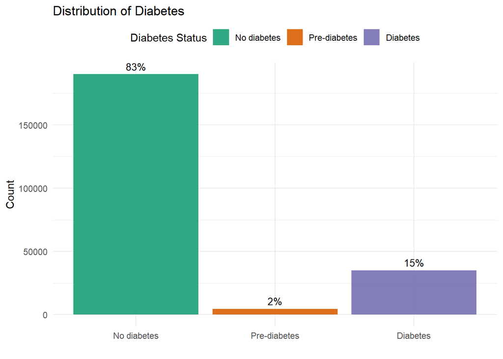

```r
ggplot(df_clean, aes(x = diabetes_012, fill = diabetes_012)) +
  geom_bar(stat = "count", alpha = 0.9) +
  stat_count(geom = "text", size = 3.5,
             aes(label = percent(after_stat(count) / sum(after_stat(count)))),
             vjust = -0.5, color = "black") +
  labs(
    title = "Distribution of Diabetes",
    x = "",
    y = "Count",
    fill = "Diabetes Status"
  ) +
  scale_fill_manual(
    values = c("No diabetes" = "#1b9e77",
               "Pre-diabetes" = "#d95f02",
               "Diabetes" = "#7570b3")
  ) +
  theme_minimal() +
  theme(legend.position = "top")
```

Biểu đồ trên cho ta thấy được:

- Dữ liệu không được cân bằng khi chỉ có khoảng 2% số người được hỏi là bị tiền tiểu đường và có khoảng 15% số người được hỏi bị mắc bệnh tiểu đường, còn lại là khoảng 83% số người được hỏi là không mắc bệnh.
- Sự mất cân bằng này có thể ảnh hưởng tiêu cực đến hiệu quả của mô hình dự đoán. Nhóm tiền tiểu đường, với số lượng nhỏ, sẽ khó được mô hình học và dự đoán chính xác, dẫn đến việc giảm độ chính xác trong phân loại và dự đoán.
- Để giải quyết vấn đề này, chúng ta có thể sử dụng kỹ thuật resampling như oversampling hoặc undersampling để cân bằng dữ liệu. Hoặc có thể điều chỉnh trọng số cho mô hình học máy để tăng độ quan trọng của nhóm thiểu số. Ngoài ra, ta cũng có thể sử dụng các phương pháp khác.

## 5.2 High_BP và Diabetes

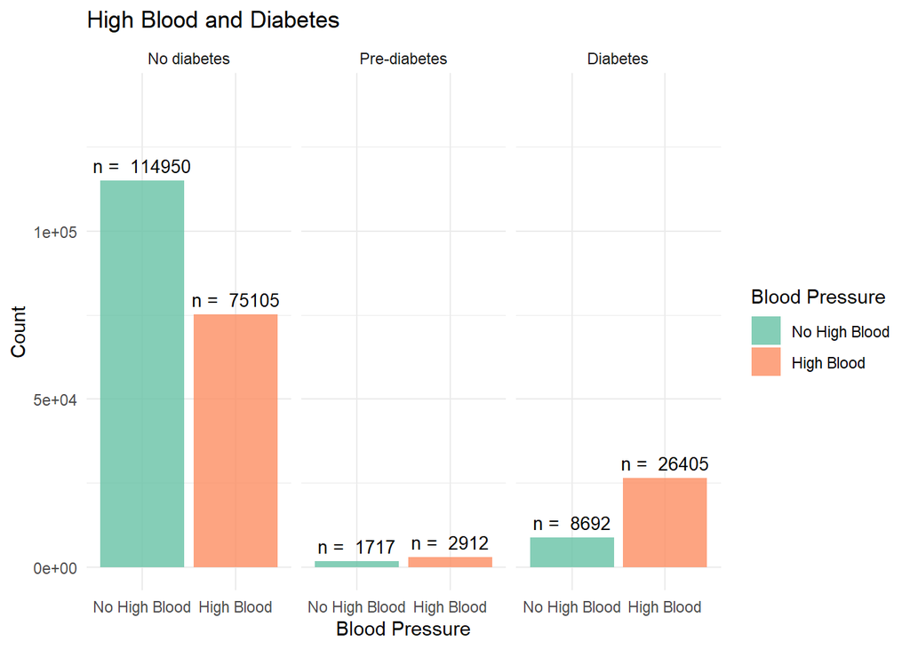

```r
ggplot(df_clean, aes(x = high_bp,
               fill = high_bp)) +
  geom_bar(stat = "count", alpha = 0.8) +
  geom_text(stat = "count", size = 3.5, aes(label = paste("n = ", after_stat(count))), vjust = -0.6, color = "black") +
  facet_wrap(~diabetes_012) +
  labs(title = "High Blood and Diabetes", x = "Blood Pressure", y = "Count", fill = "Blood Pressure") +
  theme_minimal() +
  ylim(0, 140000) +
  scale_fill_manual(
    values = c("No High Blood" = "#66c2a5",
               "High Blood" = "#fc8d62")) +
  theme(legend.position = "right")
```

```r
df_clean |> tabyl(diabetes_012, high_bp) |> adorn_percentages("row") |> adorn_pct_formatting(digits = 2)
```

| diabetes_012 | No High Blood | High Blood |
| --- | --- | --- |
| No diabetes | 60.48% | 39.52% |
| Pre-diabetes | 37.09% | 62.91% |
| Diabetes | 24.77% | 75.23% |

Qua biểu đồ và bảng tỷ số trên ta thấy được rằng:

- Biểu đồ cho thấy nhóm người bị tiền tiểu đường và tiểu đường có tỷ lệ bị cao huyết áp cao hơn đáng kể so với nhóm không bị tiểu đường. Điều này gợi ý một mối liên hệ tiềm năng giữa tình trạng tiểu đường và nguy cơ cao huyết áp.
- Ở nhóm không bị tiểu đường, tỷ lệ người bị cao huyết áp thấp hơn đáng kể so với các nhóm bị tiền tiểu đường và tiểu đường, cho thấy nguy cơ cao huyết áp tăng lên khi mức độ nghiêm trọng của tiểu đường gia tăng.
- Đáng chú ý, trong nhóm bị tiền tiểu đường và tiểu đường, tỷ lệ người bị cao huyết áp chiếm trên 60%, cho thấy tình trạng cao huyết áp rất phổ biến ở các nhóm này.

## 5.3 High Cholesterol và Diabetes

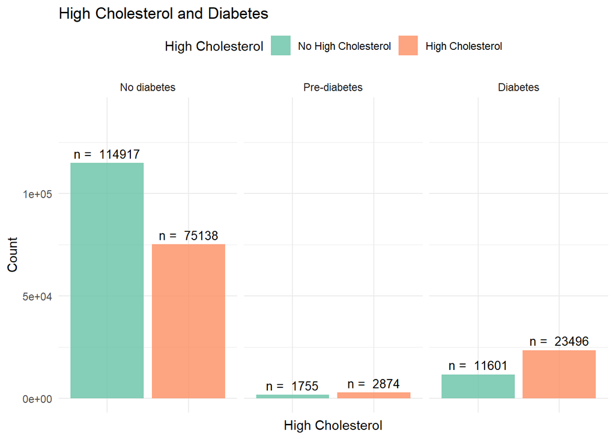

```r
ggplot(df_clean, aes(x = high_chol,
               fill = high_chol)) +
  geom_bar(stat = "count", alpha = 0.8) +
  geom_text(stat = "count", size = 3.5, aes(label = paste("n = ", after_stat(count))), vjust = -0.5, color = "black") +
  facet_wrap(~ diabetes_012) +
  labs(title = "High Cholesterol and Diabetes", x = "High Cholesterol", y = "Count", fill = "High Cholesterol") +
  theme_minimal() +
  ylim(0, 140000) +
  scale_fill_manual(values = c("No High Cholesterol" = "#66c2a5",
                               "High Cholesterol" = "#fc8d62")) +
  theme(legend.position = "top") +
  scale_x_discrete(labels = NULL)
```

```r
df_clean |> tabyl(diabetes_012, high_chol) |> adorn_percentages("row") |> adorn_pct_formatting(digits = 2)
```

| diabetes_012 | No High Cholesterol | High Cholesterol |
| --- | --- | --- |
| No diabetes | 60.47% | 39.53% |
| Pre-diabetes | 37.91% | 62.09% |
| Diabetes | 33.05% | 66.95% |

Dựa vào biểu đồ và bảng tỷ số trên ta có được một số nhận xét sau:

- Tỷ lệ người bị **cholesterol cao** tăng dần khi mức độ bị bệnh tiểu đường tăng lên. Trong nhóm không bị tiểu đường, tỷ lệ người bị cholesterol cao chiếm 39.53%, trong khi đó tỷ lệ này ở nhóm tiền tiểu đường lại tăng lên tới 62.09% và đạt tới 66.95% ở nhóm bị tiểu đường.
- Có thể thấy rằng nguy cơ bị cholesterol cao tăng lên khi mức độ nghiêm trọng của bệnh tiểu đường tăng lên.
- Điều này cho thấy có một sự liên hệ giữa bệnh tiểu đường và cholesterol cao.

## 5.4 Diabetes và Smoke

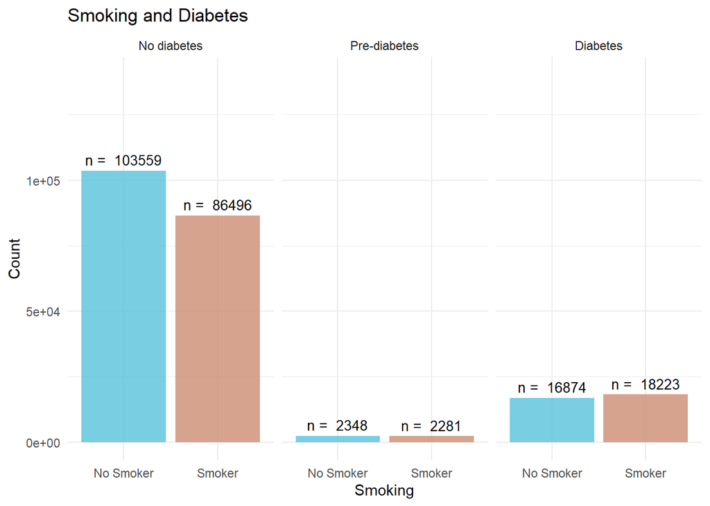

```r
ggplot(df_clean, aes(x = smoker,
               fill = smoker)) +
  geom_bar(stat = "count", alpha = 0.8) +
  geom_text(stat = "count", size = 3.5, aes(label = paste("n = ", after_stat(count))), vjust = -0.5, color = "black") +
  facet_wrap(~ diabetes_012) +
  labs(title = "Smoking and Diabetes", x = "Smoking", y = "Count", fill = "Smoking") +
  theme_minimal() +
  ylim(0, 140000) +
  scale_fill_manual(values = c("No Smoker" = "#59c2d9",
                               "Smoker" = "#cb8c72")) +
  theme(legend.position = "none")
```

```r
df_clean |> tabyl(diabetes_012, smoker) |> adorn_percentages("row") |> adorn_pct_formatting(digits = 2)
```

| diabetes_012 | No Smoker | Smoker |
| --- | --- | --- |
| No diabetes | 54.49% | 45.51% |
| Pre-diabetes | 50.72% | 49.28% |
| Diabetes | 48.08% | 51.92% |

Biểu đồ và bảng tỷ số cho ta thấy được là tỷ lệ thói quen hút thuốc dường như là tương đương bằng nhau ở cả 3 nhóm không bị tiểu đường, tiền tiểu đường và tiểu đường. Điều này cho thấy được là thói quen hút thuốc không ảnh hưởng nhiều đến nguy cơ mắc bệnh tiểu đường.

## 5.5 Sex and Diabetes

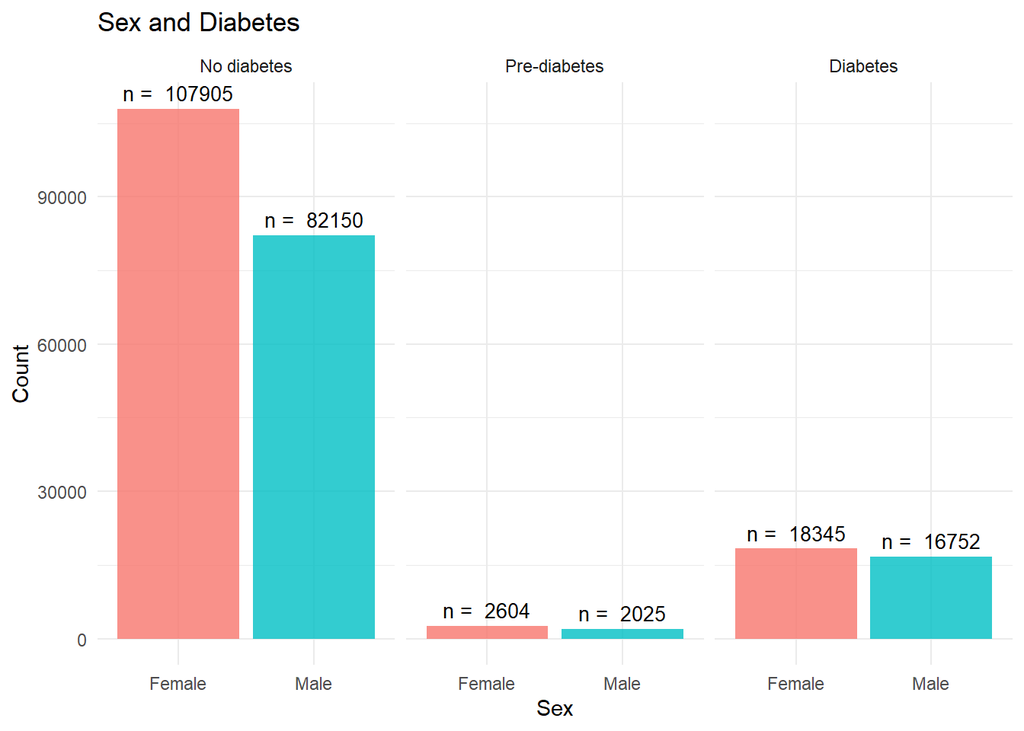

```r
ggplot(df_clean, aes(x = sex, fill = sex)) +
  geom_bar(stat = "count", alpha = 0.8) +
  geom_text(stat = "count", size = 3.5, aes(label = paste("n = ", after_stat(count))), vjust = -0.5, color = "black") +
  facet_wrap(~ diabetes_012) +
  labs(title = "Sex and Diabetes",
       x = "Sex",
       y = "Count",
       fill = "Sex") +
  theme_minimal() +
  theme(legend.position = "none")
```

- Bảng tỷ số

```r
df_clean |> tabyl(diabetes_012, sex) |> adorn_percentages("row") |> adorn_pct_formatting(digits = 2)
```

| diabetes_012 | Female | Male |
| --- | --- | --- |
| No diabetes | 56.78% | 43.22% |
| Pre-diabetes | 56.25% | 43.75% |
| Diabetes | 52.27% | 47.73% |

Biểu đồ và bảng tỷ số cho thấy được rằng không có sự khác biệt đáng kể giữa nam và nữ về tỷ lệ mắc bệnh tiểu đường. Qua đó, ta có thể kết luận rằng giới tính không ảnh hưởng nhiều đến nguy cơ mắc bệnh tiểu đường.

## 5.6 BMI and Diabetes

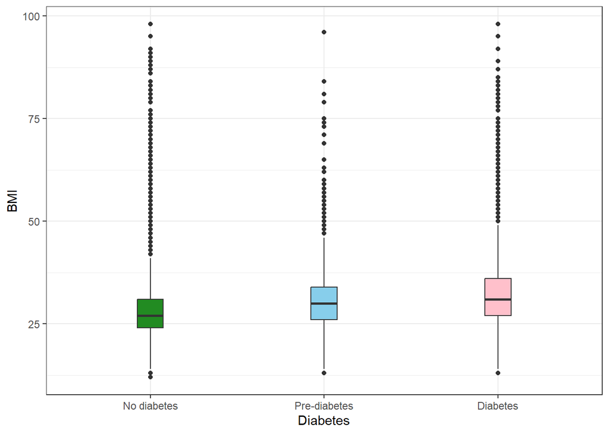

```r
ggplot(df_clean, aes(x = diabetes_012, y = bmi, fill = diabetes_012)) +
  geom_boxplot(width = 0.15) +
  scale_fill_manual(breaks = c("No diabetes", "Pre-diabetes", "Diabetes"),
                    values = c("forestgreen", "skyblue","pink")) +
  labs(x = "Diabetes", y = "BMI") +
  theme_bw() +
  theme(legend.position = "none")
```

Biểu đồ boxplot cho ta thấy được sự phân bố các giá trị BMI giữa các tình trạng bệnh tiểu đường khác nhau. Xu hướng của mỗi nhóm được thể hiện như sau:

Hình ảnh trực quan xác nhận thêm rằng khi tình trạng tiểu đường tiến triển, chỉ số BMI cũng tăng theo. Điều này làm củng cố thêm nhận định rằng có mối tương quan chặt giữa chỉ số BMI và nguy cơ của việc phát triển bệnh tiểu đường. Mặt khác, sự xuất hiện của các giá trị ngoại lai (outliers) ở cả 3 nhóm cũng chỉ ra rằng mặc dù yếu tố BMI cao là một yếu tố dự báo mạnh mẽ, nhưng không phải tất cả các trường hợp đều đúng.

## 5.7 Diabetes and Stroke

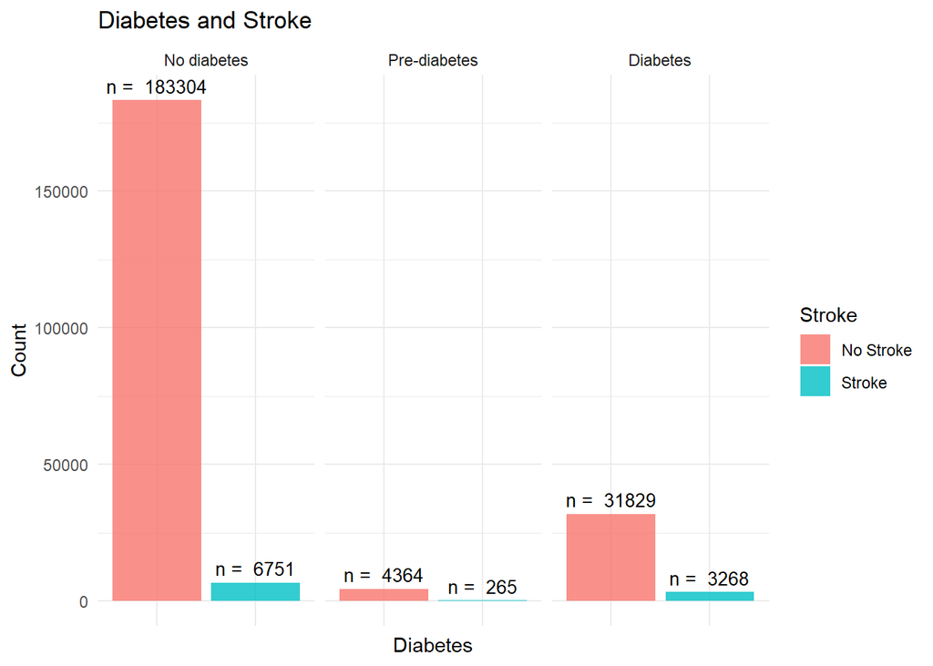

```r
ggplot(df_clean, aes(x = stroke, fill = stroke)) +
  facet_wrap(~ diabetes_012) +
  geom_bar(stat = "count", alpha = 0.8) +
  geom_text(stat = "count", size = 3.5, aes(label = paste("n = ", after_stat(count))), vjust = -0.5, color = "black") +
  labs(title = "Diabetes and Stroke",
       x = "Diabetes",
       y = "Count",
       fill = "Stroke") +
  theme_minimal() +
  theme(legend.position = "right") +
  scale_x_discrete(labels = NULL)
```

```r
df_clean |> tabyl(diabetes_012, stroke) |> adorn_percentages("row") |> adorn_pct_formatting(digits = 2)
```

| diabetes_012 | No Stroke | Stroke |
| --- | --- | --- |
| No diabetes | 96.45% | 3.55% |
| Pre-diabetes | 94.28% | 5.72% |
| Diabetes | 90.69% | 9.31% |

## 5.8 Diabetes và HeartDiseaseorAttack

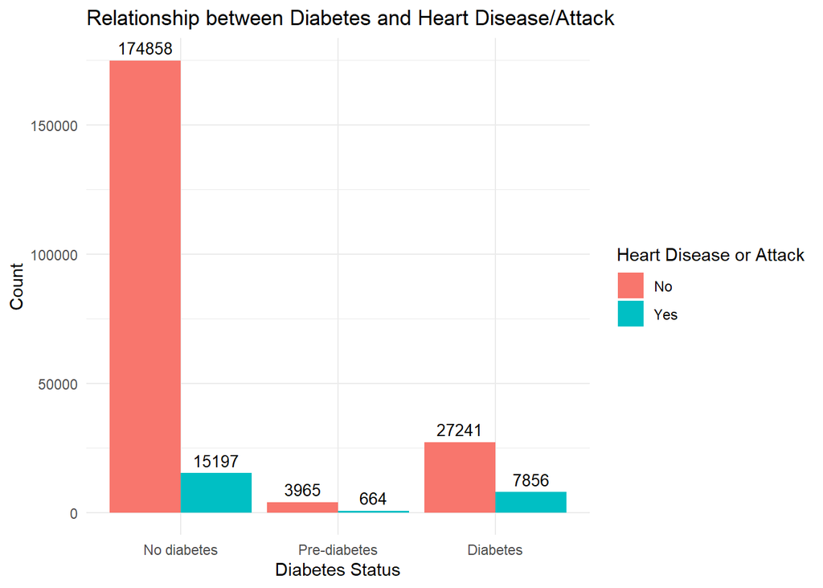

```r
ggplot(df_clean, aes(x = diabetes_012, fill = heart_diseaseor_attack)) +
  geom_bar(position = "dodge") +
  geom_text(stat = "count",
            aes(label = after_stat(count), group = heart_diseaseor_attack),
            position = position_dodge(width = 0.9),
            vjust = -0.5,
            size = 3.5,
            color = "black") +
  labs(title = "Relationship between Diabetes and Heart Disease/Attack",
       x = "Diabetes Status",
       y = "Count",
       fill = "Heart Disease or Attack") +
  theme_minimal() +
  theme(legend.position = "right")
```

```r
df_clean |> tabyl(diabetes_012, heart_diseaseor_attack) |> adorn_percentages("row") |> adorn_pct_formatting(digits = 2)
```

| diabetes_012 | No | Yes |
| --- | --- | --- |
| No diabetes | 92.00% | 8.00% |
| Pre-diabetes | 85.66% | 14.34% |
| Diabetes | 77.62% | 22.38% |

- Tỷ lệ người đã từng được chẩn đoán mắc bệnh tim mạch vành (CHD) hoặc nhồi máu cơ tim (MI) trong quá khứ tăng dần khi chuyển từ nhóm **Không tiểu đường (8%)** sang **Tiền tiểu đường (14.34%)** và cao nhất ở nhóm **Tiểu đường (22.38%)**.
- Điều này cho thấy một mối liên hệ tiềm năng giữa tình trạng bệnh tiểu đường `diabetes_012` và khả năng từng được chẩn đoán mắc bệnh tim mạch vành (CHD) hoặc nhồi máu cơ tim (MI) trong `heart_diseaseor_attack`.
- Những người bị **Diabetes** có nguy cơ cao hơn đáng kể trong việc từng được chẩn đoán mắc bệnh tim mạch hoặc nhồi máu cơ tim so với nhóm **No diabetes**. Tương tự, nhóm **Pre-diabetes** cũng có nguy cơ cao hơn nhóm **No diabetes**, nhưng mức độ thấp hơn so với nhóm **Diabetes**.
- Dù vậy, có 8% người thuộc nhóm **No diabetes** vẫn từng được chẩn đoán mắc bệnh tim mạch hoặc nhồi máu cơ tim. Điều này cho thấy bệnh tiểu đường không phải là yếu tố duy nhất dẫn đến tình trạng bệnh lý tim mạch này, mà có thể còn phụ thuộc vào các yếu tố nguy cơ khác.

## 5.9 Kiểm tra mối liên hệ giữa biến `diabetes_012` và các biến phân loại khác như `age`, `income`, `education` và `gen_hlth`.

Để kiểm tra mối liên hệ của biến `diabetes_012` với các biến phân loại khác như `age`, `income`, `education` và `gen_hlth`, ta sẽ sử dụng kiểm định Chi-square với mức ý nghĩa $\alpha = 0.05$ cho từng cặp biến nhằm kiểm tra tính độc lập giữa chúng.

- Giữa `diabetes_012` và `age`:

```r
result_chisq_1 = chisq.test(table(df_clean$diabetes_012, df_clean$age))
result_chisq_1
```

```
##
##  Pearson's Chi-squared test
##
## data:  table(df_clean$diabetes_012, df_clean$age)
## X-squared = 8975.7, df = 24, p-value < 2.2e-16
```

```r
if(result_chisq_1$p.value < 0.05)
{
    print("Reject H0")
} else
  {
    print("Not Reject H0")
  }
```

```
## [1] "Reject H0"
```

Dựa vào kết quả trên, với mức ý nghĩa 5%, ta có thể khẳng định rằng biến `diabetes_012` và `age` không độc lập với nhau. Qua đó ta có thể nói được rằng có sự liên hệ (phụ thuộc) giữa 2 biến `diabetes_012` và `age`.

- Giữa `diabetes_012` và `income`:

```r
result_chisq_2 = chisq.test(table(df_clean$diabetes_012, df_clean$income))
result_chisq_2
```

```
##
##  Pearson's Chi-squared test
##
## data:  table(df_clean$diabetes_012, df_clean$income)
## X-squared = 5154.4, df = 14, p-value < 2.2e-16
```

```r
if(result_chisq_2$p.value < 0.05)
{
    print("Reject H0")
} else
  {
    print("Not Reject H0")
  }
```

```
## [1] "Reject H0"
```

Dựa vào kết quả trên, với mức ý nghĩa 5%, ta có thể khẳng định rằng biến `diabetes_012` và `income` không độc lập với nhau. Qua đó ta có thể nói được rằng có sự liên hệ (phụ thuộc) giữa 2 biến `diabetes_012` và `income`.

- Giữa `diabetes_012` và `education`:

```r
result_chisq_3 = chisq.test(table(df_clean$education, df_clean$diabetes_012))
result_chisq_3
```

```
##
##  Pearson's Chi-squared test
##
## data:  table(df_clean$education, df_clean$diabetes_012)
## X-squared = 2853.7, df = 10, p-value < 2.2e-16
```

```r
if(result_chisq_3$p.value < 0.05)
{
    print("Reject H0")
} else
  {
    print("Not Reject H0")
  }
```

```
## [1] "Reject H0"
```

Dựa vào kết quả trên, với mức ý nghĩa 5%, ta có thể khẳng định rằng biến `diabetes_012` và `education` không độc lập với nhau. Qua đó ta có thể nói được rằng có sự liên hệ (phụ thuộc) giữa 2 biến `diabetes_012` và `education`.

- Giữa `diabetes_012` và `gen_hlth`:

```r
result_chisq_4 = chisq.test(table(df_clean$gen_hlth, df_clean$diabetes_012))
result_chisq_4
```

```
##
##  Pearson's Chi-squared test
##
## data:  table(df_clean$gen_hlth, df_clean$diabetes_012)
## X-squared = 19340, df = 8, p-value < 2.2e-16
```

```r
if(result_chisq_4$p.value < 0.05)
{
    print("Reject H0")
} else
  {
    print("Not Reject H0")
  }
```

```
## [1] "Reject H0"
```

Dựa vào kết quả trên, với mức ý nghĩa 5%, ta có thể khẳng định rằng biến `diabetes_012` và `gen_hlth` không độc lập với nhau. Qua đó ta có thể nói được rằng có sự liên hệ (phụ thuộc) giữa 2 biến `diabetes_012` và `gen_hlth`.

## 5.10 Diabetes với Men_Hlth và Phys_Hlth

Ta sử dụng biểu đồ boxplot để trực quan hóa mối liên hệ giữa biến `diabetes_012` với `men_hlth` và `phys_hlth`.

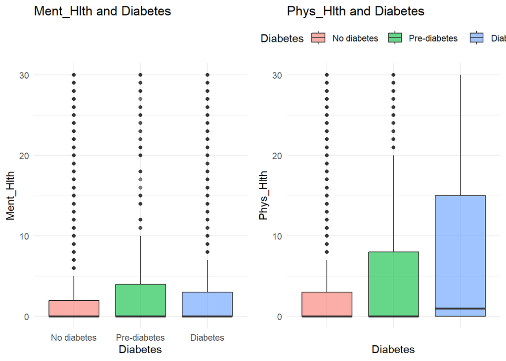

```r
library(cowplot)
plot1 = ggplot(df_clean, aes(x = diabetes_012, y = ment_hlth, fill = diabetes_012)) +
  geom_boxplot(alpha = 0.6) +
  labs(title = "Ment_Hlth and Diabetes", x = "Diabetes", y = "Ment_Hlth", fill = "Diabetes") +
  theme_minimal() +
  theme(legend.position = "none")

plot2 = ggplot(df_clean, aes(x = diabetes_012, y = phys_hlth, fill = diabetes_012)) +
  geom_boxplot(alpha = 0.6) +
  labs(title = "Phys_Hlth and Diabetes", x = "Diabetes", y = "Phys_Hlth", fill = "Diabetes") +
  theme_minimal() +
  theme(legend.position = "top") +
  scale_x_discrete(labels = NULL)

plot_grid(plot1, plot2, ncol = 2, align = "h")
```

Từ biểu đồ trên, ta có thể thấy rằng:

1. **Ment_Hlth và Diabetes_012**:
   - Phân phối các giá trị của `ment_hlth` tương đối giống nhau ở cả 3 nhóm: không bị tiểu đường *(No Diabetes)*, tiền tiểu đường *(Pre-Diabetes)* và bị tiểu đường *(Diabetes)*.
   - Điều này cho thấy rằng không có sự khác biệt đáng kể về sức khỏe tinh thần giữa 3 nhóm này.
2. **Phys_Hlth và Diabetes_012**:
   - Nhóm bị tiểu đường *(Diabetes)* có sự phân tán lớn hơn và có giá trị trung vị cao hơn so với 2 nhóm còn lại. Điều này cho thấy nhóm này có số ngày không khỏe về mặt thể chất nhiều hơn so với 2 nhóm còn lại.
   - Nhóm tiền tiểu đường *(Pre-Diabetes)* có khoảng tứ phân vị lớn hơn nhóm không bị tiểu đường nhưng lại nhỏ hơn nhóm bị tiểu đường, mặt khác nhóm này còn có các giá trị ngoại lai *(outliers)*.

Hình ảnh trực quan xác nhận thêm rằng khi tình trạng tiểu đường tiến triển, chỉ số về số ngày không khoẻ về mặt thể chất cũng tăng theo. Điều này làm củng cố thêm nhận định rằng có mối tương quan giữa chỉ số về số ngày không khoẻ về mặt thể chất `phys_hlth`. Mặt khác, sự xuất hiện các giá trị ngoại lai ở nhóm không tiểu đường và tiền tiểu đường cũng cho thấy rằng không thể khẳng định rõ được là biến `phys_hlth` có ảnh hưởng lớn đến việc xác định nguy cơ bệnh tiểu đường hay không. Điều này cũng tương tự với biến `ment_hlth` trong việc xác định nguy cơ bệnh tiểu đường.

## 5.11 Diabetes và Fruits

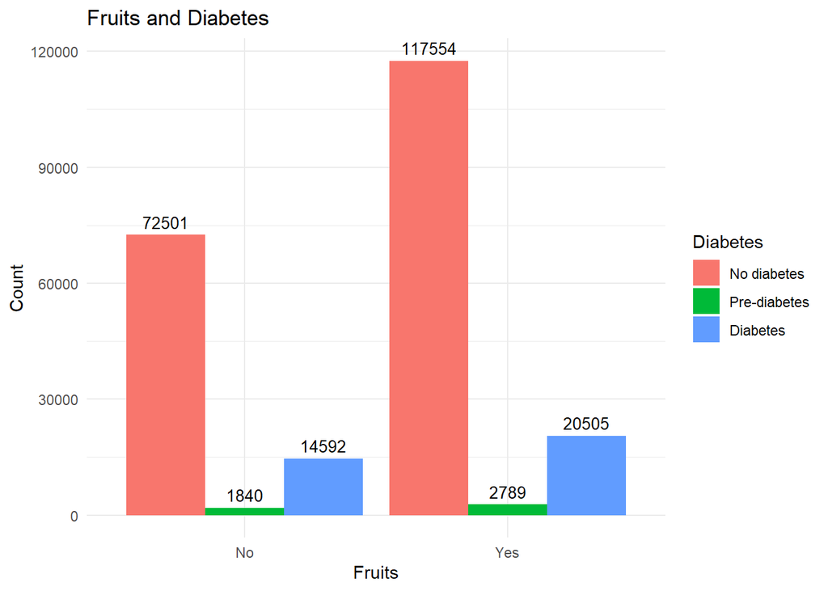

```r
ggplot(df_clean, aes(x = fruits, fill = diabetes_012)) +
  geom_bar(position = "dodge") +
  geom_text(stat = "count",
            aes(label = after_stat(count), group = diabetes_012),
            position = position_dodge(width = 0.9),
            vjust = -0.5,
            size = 3.5,
            color = "black") +
  labs(title = "Fruits and Diabetes",
       x = "Fruits",
       y = "Count",
       fill = "Diabetes") +
  theme_minimal() +
  theme(legend.position = "right")
```

Biểu đồ trên cho thấy được rằng việc tiêu thụ trái cây ít nhất 1 lần mỗi ngày sẽ có thể làm giảm nguy cơ mắc bệnh tiểu đường.

## 5.12 Diabetes và Veggies

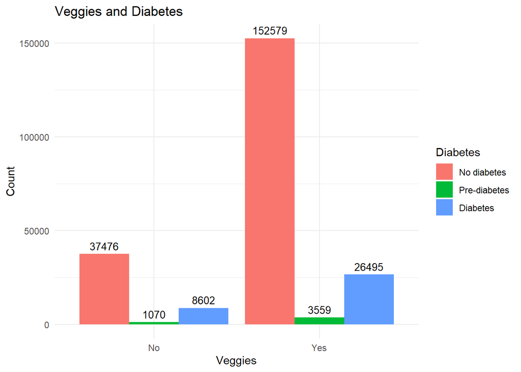

```r
ggplot(df_clean, aes(x = veggies, fill = diabetes_012)) +
  geom_bar(position = "dodge") +
  geom_text(stat = "count",
            aes(label = after_stat(count), group = diabetes_012),
            position = position_dodge(width = 0.9),
            vjust = -0.5,
            size = 3.5,
            color = "black") +
  labs(title = "Veggies and Diabetes",
       x = "Veggies",
       y = "Count",
       fill = "Diabetes") +
  theme_minimal() +
  theme(legend.position = "right")
```

Tương tự với việc tiêu thụ trái cây ít nhất 1 lần mỗi ngày *(fruits)* thì việc tiêu thụ rau củ ít nhất 1 lần mỗi ngày *(Veggies)* cũng giúp giảm nguy cơ mắc bệnh tiểu đường.

Từ quá trình khám phá phân tích dữ liệu trên, ta có được các biến quan trọng có thể ảnh hưởng đến nguy cơ mắc bệnh tiểu đường như `high_bp`, `high_chol`, `bmi`, `phys_hlth`, `ment_hlth`, `gen_hlth`, `age`, `income`, `education`, `heart_diseaseor_attack`, `veggies` và `fruits`.

# 6. Đặt câu hỏi và mục tiêu

Mục tiêu của bài báo cáo này là phân tích các yếu tố sức khỏe có liên quan đến bệnh tiểu đường, đánh giá mức độ tương quan giữa các yếu tố này và xác định các yếu tố nguy cơ chính. Từ đó, hỗ trợ việc xây dựng các mô hình dự đoán hiệu quả nhằm cải thiện khả năng nhận diện sớm và quản lý bệnh tiểu đường.

Để đạt được mục tiêu này, bài báo cáo sẽ tập trung vào việc trả lời các câu hỏi sau:

1. **Các yếu tố sức khỏe nào có tương quan đáng kể với nguy cơ mắc bệnh tiểu đường?**

   Sử dụng phân tích thống kê và kiểm định giả thuyết (A/B Testing) để kiểm tra mối liên hệ giữa từng yếu tố sức khỏe với tình trạng bệnh tiểu đường.
2. **Mô hình logistic regression có thể dự đoán khả năng mắc bệnh tiểu đường dựa trên các yếu tố sức khỏe không? Nếu có, mô hình này có hiệu quả ra sao?**

   Áp dụng kỹ thuật mô hình hóa dữ liệu (logistic regression) để xây dựng và đánh giá mô hình dự đoán.

Phương pháp:

**A/B Testing:** So sánh giữa hai nhóm (ví dụ: nhóm mắc bệnh và nhóm không mắc bệnh) để kiểm tra các yếu tố sức khỏe như mức độ vận động, chế độ ăn uống, hoặc chỉ số BMI có ảnh hưởng đáng kể đến bệnh tiểu đường hay không.

**Mô hình hóa dữ liệu:** Sử dụng logistic regression để xác định mối quan hệ giữa các biến giải thích (các yếu tố sức khỏe) và biến phụ thuộc (tình trạng mắc bệnh tiểu đường), từ đó đánh giá khả năng dự đoán và ý nghĩa thống kê của từng yếu tố.

# 7. Kiểm định Chi-square và A/B Testing

Để làm rõ hơn quyết định ở phía trên, ta sẽ thực hiện kiểm định Chi-square để kiểm tra tính độc lập giữa các biến nhị phân và biến phản hồi `diabetes_012`.

## 7.1 Kiểm định Chi-square

- Kiểm tra sự độc lập giữa biến `diabetes_012` và các biến nhị phân khác.

```r
vars = c("high_bp", "high_chol", "chol_check", "smoker","stroke","heart_diseaseor_attack","phys_activity",
          "fruits","veggies","hvy_alcohol_consump","any_healthcare","no_docbc_cost","diff_walk","sex")

for (var in vars)
{
  test_result = chisq.test(table(df_clean$diabetes_012, df[[var]]))
  is_independent = test_result$p.value > 0.05
  cat("Is diabetes_012 and", var, "independent of each other?", is_independent, "\n")
}
```

```
## Is diabetes_012 and high_bp independent of each other? FALSE
## Is diabetes_012 and high_chol independent of each other? FALSE
## Is diabetes_012 and chol_check independent of each other? FALSE
## Is diabetes_012 and smoker independent of each other? FALSE
## Is diabetes_012 and stroke independent of each other? FALSE
## Is diabetes_012 and heart_diseaseor_attack independent of each other? FALSE
## Is diabetes_012 and phys_activity independent of each other? FALSE
## Is diabetes_012 and fruits independent of each other? FALSE
## Is diabetes_012 and veggies independent of each other? FALSE
## Is diabetes_012 and hvy_alcohol_consump independent of each other? FALSE
## Is diabetes_012 and any_healthcare independent of each other? FALSE
## Is diabetes_012 and no_docbc_cost independent of each other? FALSE
## Is diabetes_012 and diff_walk independent of each other? FALSE
## Is diabetes_012 and sex independent of each other? FALSE
```

Kết quả cho thấy, có sự liên hệ **(phụ thuộc)** với nhau giữa biến diabetes_012 và các biến nhị thức khác có trong bộ dữ liệu.

## 7.2 ANOVA cho trung bình biến BMI theo từng nhóm của `diabetes_012`

Ta sẽ kiểm tra xem sự khác biệt trung bình giữa biến `bmi` trong bộ dữ liệu theo các nhóm trong biến `diabetes_012` là có ý nghĩa thống kê hay không.

```r
df_clean |> group_by(diabetes_012) |> summarise(n=n(),mean_bmi=mean(bmi),sd_bmi=sd(bmi))
```

| diabetes_012 | n | mean_bmi | sd_bmi |
| --- | --- | --- | --- |
| No diabetes | 190055 | 28.03053 | 6.474981 |
| Pre-diabetes | 4629 | 30.72607 | 6.965973 |
| Diabetes | 35097 | 31.96424 | 7.380385 |

```r
new_df_bmi = data.frame(diabetes = df_clean$diabetes_012, bmi = df_clean$bmi)
glimpse(new_df_bmi)
```

```
## Rows: 229,781
## Columns: 2
## $ diabetes <fct> No diabetes, No diabetes, No diabetes, No diabetes, No diabet…
## $ bmi      <dbl> 40, 25, 28, 27, 24, 25, 30, 25, 30, 24, 25, 34, 26, 28, 33, 3…
```

```r
# ggplot(new_df_bmi, aes(x = diabetes, y = bmi, fill = diabetes)) +
#   geom_boxplot(width = 0.15) +
#   scale_fill_manual(breaks = c("No diabetes", "Pre-diabetes", "Diabetes"),
#                     values = c("forestgreen", "skyblue","pink")) +
#   labs(x = "Diabetes", y = "BMI") +
#   theme_bw() +
#   theme(legend.position = "none")
```

```r
set.seed(42)
df_aov = aov(formula = bmi ~ diabetes_012, data = df_clean)
summary(df_aov)
```

```
##                  Df   Sum Sq Mean Sq F value Pr(>F)
## diabetes_012      2   478104  239052    5436 <2e-16 ***
## Residuals    229778 10104342      44
## ---
## Signif. codes:  0 '***' 0.001 '**' 0.01 '*' 0.05 '.' 0.1 ' ' 1
```

Do $p-value<0.05$ nên sự khác biệt trung bình `bmi` giữa các nhóm `diabetes_012` là có ý nghĩa thống kê.

# 8. Mô hình hóa dữ liệu

Sử dụng để xác định khả năng dự đoán khả năng mắc bệnh tiểu đường dựa trên các yếu tố sức khỏe.

Nhận thấy rằng tiền tiểu đường cũng tương tự như tiểu đường, nên ta sẽ gộp nhóm Tiền tiểu đường vào nhóm Tiểu đường. Thay vì tạo ra một mô hình để xác định xem một người có nguy cơ mắc bệnh tiểu đường, có nguy cơ bị tiền tiểu đường, hay không có nguy cơ mắc bệnh tiểu đường thì mô hình bây giờ chỉ xác định xem một người có nguy cơ mắc bệnh tiểu đường hoặc là không.

```r
df_clean$diabetes_012 = as.character(df_clean$diabetes_012)
df_clean$diabetes_012 = as.factor(ifelse(df_clean$diabetes_012 == "No diabetes", "No diabetes", "Diabetes"))
df_clean$diabetes_012 = factor(df_clean$diabetes_012, levels = c("No diabetes", "Diabetes"))
```

Trước khi xây dựng mô hình, ta sẽ vẽ biểu đồ tương quan giữa các biến định lượng và biến phản hồi (diabetes_012) trong dữ liệu gốc `df` ban đầu để xác định mức độ tương quan giữa chúng.

Tạo ma trận tương quan cho các biến.

```r
corr_matrix = cor(df, method = "pearson")
corr_table = as.data.frame(round(corr_matrix, 2))
datatable(
  corr_table,
  options = list(
    scrollX = TRUE,
    pageLength = 22
  )) |> htmltools::tags$div(
    style = "font-size: 12px; width: 80%; margin: auto;" )
```

|  | diabetes_012 | high_bp | high_chol | chol_check | bmi | smoker | stroke | heart_diseaseor_attack | phys_activity | fruits | veggies | hvy_alcohol_consump | any_healthcare | no_docbc_cost | gen_hlth | ment_hlth | phys_hlth | diff_walk | sex | age | education | income |
| --- | --- | --- | --- | --- | --- | --- | --- | --- | --- | --- | --- | --- | --- | --- | --- | --- | --- | --- | --- | --- | --- | --- |
| diabetes_012 | 1 | 0.26 | 0.2 | 0.08 | 0.21 | 0.05 | 0.1 | 0.17 | -0.1 | -0.03 | -0.04 | -0.07 | 0.02 | 0.02 | 0.28 | 0.06 | 0.16 | 0.21 | 0.03 | 0.18 | -0.11 | -0.15 |
| high_bp | 0.26 | 1 | 0.28 | 0.11 | 0.19 | 0.07 | 0.12 | 0.2 | -0.1 | -0.02 | -0.04 | -0.01 | 0.05 | 0 | 0.27 | 0.04 | 0.14 | 0.21 | 0.05 | 0.34 | -0.11 | -0.14 |
| high_chol | 0.2 | 0.28 | 1 | 0.09 | 0.09 | 0.07 | 0.09 | 0.18 | -0.06 | -0.03 | -0.03 | -0.02 | 0.05 | 0 | 0.19 | 0.05 | 0.11 | 0.14 | 0.02 | 0.26 | -0.05 | -0.06 |
| chol_check | 0.08 | 0.11 | 0.09 | 1 | 0.04 | 0 | 0.03 | 0.05 | 0 | 0.02 | 0 | -0.02 | 0.12 | -0.05 | 0.06 | 0 | 0.04 | 0.05 | -0.02 | 0.1 | -0.01 | 0 |
| bmi | 0.21 | 0.19 | 0.09 | 0.04 | 1 | -0.01 | 0.01 | 0.04 | -0.13 | -0.07 | -0.04 | -0.06 | -0.01 | 0.05 | 0.21 | 0.07 | 0.1 | 0.18 | 0.03 | -0.05 | -0.07 | -0.07 |
| smoker | 0.05 | 0.07 | 0.07 | 0 | -0.01 | 1 | 0.05 | 0.11 | -0.07 | -0.06 | -0.01 | 0.1 | -0.01 | 0.04 | 0.13 | 0.08 | 0.1 | 0.11 | 0.1 | 0.11 | -0.14 | -0.1 |
| stroke | 0.1 | 0.12 | 0.09 | 0.03 | 0.01 | 0.05 | 1 | 0.2 | -0.06 | 0 | -0.03 | -0.02 | 0.01 | 0.03 | 0.17 | 0.06 | 0.14 | 0.17 | 0 | 0.13 | -0.06 | -0.12 |
| heart_diseaseor_attack | 0.17 | 0.2 | 0.18 | 0.05 | 0.04 | 0.11 | 0.2 | 1 | -0.07 | -0.01 | -0.03 | -0.04 | 0.03 | 0.02 | 0.25 | 0.05 | 0.17 | 0.2 | 0.09 | 0.22 | -0.08 | -0.12 |
| phys_activity | -0.1 | -0.1 | -0.06 | 0 | -0.13 | -0.07 | -0.06 | -0.07 | 1 | 0.13 | 0.14 | 0.02 | 0.02 | -0.05 | -0.24 | -0.11 | -0.2 | -0.24 | 0.03 | -0.09 | 0.17 | 0.17 |
| fruits | -0.03 | -0.02 | -0.03 | 0.02 | -0.07 | -0.06 | 0 | -0.01 | 0.13 | 1 | 0.24 | -0.03 | 0.02 | -0.03 | -0.07 | -0.05 | -0.02 | -0.03 | -0.09 | 0.07 | 0.09 | 0.05 |

[output cut: 12 more lines]

Vẽ biểu đồ tương quan của các biến định lượng để kiểm tra hệ số tương quan của từng cặp biến trong dữ liệu. Sử dụng hàm `corrplot()` trong thư viện `corrplot`.

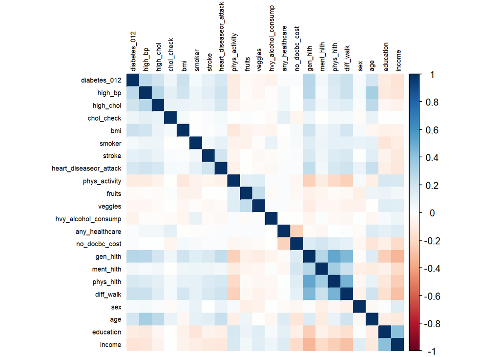

```r
corrplot(corr_matrix,
         method = "color",
         tl.col = "black",
         tl.cex = 0.55,
         insig = "blank")
```

Dựa vào ma trận và biểu đồ tương quan trên, ta có thể nhận thấy được mối quan hệ giữa biến `diabetes_012` và các biến khác trong dữ liệu như sau:

## 8.1 Xây dựng mô hình

Dựa vào các biến trên ta có thể xây dựng được rất nhiều mô hình. Vì biến phản hồi (Y) là biến nhị phân nên mô hình phù hợp nhất là mô hình logistic regression.

Từ các quá trình khám phá phân tích dữ liệu và biểu đồ tương quan đã phân tích trước đó, ta sẽ chọn ra các biến sau: `high_bp`, `high_chol`, `bmi`, `phys_hlth`, `ment_hlth`, `gen_hlth`, `age`, `income`, `education`, `heart_diseaseor_attack`, `stroke` để xây dựng mô hình.

Khi đó ta có được mô hình sau:

$$\log \frac{p(x)}{1 - p(x)} = \beta_0 +
\beta_1 \text{high_bp} + \beta_2 \text{high_chol} + \beta_3 \text{bmi} +
\beta_4 \text{phys_hlth} + \\ \beta_5 \text{ment_hlth} + \beta_6
\text{gen_hlth} + \beta_7 \text{age} + \beta_8 \text{income} + \beta_9
\text{education} + \beta_{10} \text{heart_diseaseor_attack} + \beta_{11}
\text{stroke}$$

```r
logistic_md = glm(diabetes_012 ~ high_bp +
                    high_chol +
                    bmi +
                    phys_hlth +
                    ment_hlth +
                    gen_hlth +
                    age +
                    income +
                    education +
                    heart_diseaseor_attack +
                    stroke,
                  data = df_clean, family = "binomial")
```

- Kiểm tra hiện tượng đa cộng tuyến bằng hàm `vif`.

```r
vif(logistic_md)
```

```
##                            GVIF Df GVIF^(1/(2*Df))
## high_bp                1.127256  1        1.061723
## high_chol              1.069771  1        1.034297
## bmi                    1.095414  1        1.046620
## phys_hlth              1.689652  1        1.299866
## ment_hlth              1.251609  1        1.118753
## gen_hlth               1.870750  4        1.081439
## age                    1.301735 12        1.011048
## income                 1.476939  7        1.028247
## education              1.305536  5        1.027020
## heart_diseaseor_attack 1.130010  1        1.063019
## stroke                 1.067232  1        1.033069
```

Với $j = \overline{1, 11}$, ta thấy rằng $VIF_{j}$ đều nhỏ hơn 5. Do đó, ta kết luận rằng không có hiện tượng đa cộng tuyến trong mô hình.

Kết quả tổng hợp như sau:

```r
summary(logistic_md)
```

```
##
## Call:
## glm(formula = diabetes_012 ~ high_bp + high_chol + bmi + phys_hlth +
##     ment_hlth + gen_hlth + age + income + education + heart_diseaseor_attack +
##     stroke, family = "binomial", data = df_clean)
##
## Coefficients:
##                             Estimate Std. Error z value Pr(>|z|)
## (Intercept)               -6.4641673  0.2193616 -29.468  < 2e-16 ***
## high_bpHigh Blood          0.6791728  0.0138380  49.080  < 2e-16 ***
## high_cholHigh Cholesterol  0.5538696  0.0129371  42.813  < 2e-16 ***
## bmi                        0.0588584  0.0008659  67.975  < 2e-16 ***
## phys_hlth                 -0.0021946  0.0007482  -2.933 0.003356 **
## ment_hlth                 -0.0030894  0.0008010  -3.857 0.000115 ***
## gen_hlthVery Good          0.6147576  0.0303114  20.281  < 2e-16 ***
## gen_hlthGood               1.2234423  0.0295070  41.463  < 2e-16 ***
## gen_hlthFair               1.6812483  0.0320150  52.514  < 2e-16 ***
## gen_hlthPoor               1.8642341  0.0389416  47.873  < 2e-16 ***
## age2                       0.2380207  0.1281222   1.858 0.063203 .
## age3                       0.4264564  0.1170058   3.645 0.000268 ***
## age4                       0.8762618  0.1109239   7.900 2.80e-15 ***
## age5                       1.0815244  0.1086848   9.951  < 2e-16 ***
## age6                       1.3340694  0.1069542  12.473  < 2e-16 ***
## age7                       1.5227579  0.1058449  14.387  < 2e-16 ***
## age8                       1.6181657  0.1054446  15.346  < 2e-16 ***
## age9                       1.8433531  0.1052061  17.521  < 2e-16 ***
## age10                      1.9998605  0.1051953  19.011  < 2e-16 ***
## age11                      2.0543422  0.1055531  19.463  < 2e-16 ***
## age12                      1.9790696  0.1061892  18.637  < 2e-16 ***
## age13                      1.8186682  0.1062751  17.113  < 2e-16 ***
## income2                   -0.0284621  0.0340915  -0.835 0.403790
## income3                   -0.0724238  0.0328155  -2.207 0.027314 *
## income4                   -0.1074446  0.0321312  -3.344 0.000826 ***
## income5                   -0.1683231  0.0316138  -5.324 1.01e-07 ***
## income6                   -0.2367878  0.0310100  -7.636 2.24e-14 ***
## income7                   -0.2594555  0.0312150  -8.312  < 2e-16 ***
## income8                   -0.3456297  0.0306664 -11.271  < 2e-16 ***
## education2                 0.1580255  0.1922643   0.822 0.411124
## education3                 0.0101114  0.1903925   0.053 0.957646
## education4                -0.1017247  0.1890889  -0.538 0.590596
## education5                -0.0729971  0.1891572  -0.386 0.699566
## education6                -0.1193565  0.1892674  -0.631 0.528287
## heart_diseaseor_attackYes  0.2699509  0.0170740  15.811  < 2e-16 ***
## strokeStroke               0.1451967  0.0242197   5.995 2.03e-09 ***
## ---
## Signif. codes:  0 '***' 0.001 '**' 0.01 '*' 0.05 '.' 0.1 ' ' 1
##
## (Dispersion parameter for binomial family taken to be 1)
##
##     Null deviance: 211598  on 229780  degrees of freedom
## Residual deviance: 172085  on 229745  degrees of freedom
## AIC: 172157
##
## Number of Fisher Scoring iterations: 6
```

Tiếp theo, ta áp dụng phương pháp bootstrap để ước lượng khoảng tin cậy và kiểm định giả thuyết $\beta_j = 0$. Tức là ta đi kiểm tra cặp **Giả thuyết** và **Đối thuyết** sau:

- **Giả thuyết:** $\beta_j = 0$.
- **Đối thuyết:** $\beta_j \neq 0$.

Kiểm định *Giả thuyết* này tương đương với việc trả lời câu hỏi: *“Có sự tồn tại mối liên hệ giữa biến $X_j$ và $Y$ hay không?”*.

Định nghĩa hàm để thực hiện ước tính mỗi lần lặp lấy mẫu:

```r
function_boot = function(df, index, formula, ...)
{
    df_new = df[index, ]
    out_md = speedglm(formula = formula, data = df_new, family = binomial(), ...)
    return(out_md$coefficients)
}
```

Thực hiện bootstrap:

```r
set.seed(124)

df_temp = df_clean[, c("diabetes_012", "high_bp", "high_chol", "bmi", "phys_hlth",
                         "ment_hlth", "gen_hlth", "age", "income", "education",
                         "heart_diseaseor_attack", "stroke")]


out_boot_md = boot(data = df_temp,
                        statistic = function_boot,
                        R = 500,
                        formula = diabetes_012 ~ high_bp +
                     high_chol +
                     bmi +
                     phys_hlth +
                     ment_hlth +
                     gen_hlth +
                     age +
                     income +
                     education +
                     heart_diseaseor_attack +
                     stroke)
out_boot_md
```

```
##
## ORDINARY NONPARAMETRIC BOOTSTRAP
##
##
## Call:
## boot(data = df_temp, statistic = function_boot, R = 500, formula = diabetes_012 ~
##     high_bp + high_chol + bmi + phys_hlth + ment_hlth + gen_hlth +
##         age + income + education + heart_diseaseor_attack + stroke)
##
##
## Bootstrap Statistics :
##          original        bias     std. error
## t1*  -6.464167260 -2.093119e-02 0.2203856303
## t2*   0.679172783 -1.457526e-03 0.0140654228
## t3*   0.553869647 -6.587983e-04 0.0132764518
## t4*   0.058858430  1.214744e-04 0.0008942023
## t5*  -0.002194595 -5.327527e-05 0.0007212058
## t6*  -0.003089417  2.269292e-05 0.0007875726
## t7*   0.614757612  1.764948e-03 0.0301750283
## t8*   1.223442266  1.489604e-03 0.0302799121
## t9*   1.681248263  1.177544e-03 0.0317765733
## t10*  1.864234094  1.895063e-03 0.0380832882
## t11*  0.238020672  7.764747e-03 0.1411068579
## t12*  0.426456411  9.288735e-03 0.1185877914
## t13*  0.876261776  9.010169e-03 0.1171950981
## t14*  1.081524427  1.109820e-02 0.1159373666
## t15*  1.334069442  1.025360e-02 0.1127540281
## t16*  1.522757920  1.245332e-02 0.1128016781
## t17*  1.618165699  1.090788e-02 0.1133297108
## t18*  1.843353073  1.227653e-02 0.1121552180
## t19*  1.999860463  1.258074e-02 0.1123162526
## t20*  2.054342230  1.204030e-02 0.1118026801
## t21*  1.979069648  1.164358e-02 0.1096964167
## t22*  1.818668197  1.346462e-02 0.1128130304
## t23* -0.028462052  2.285072e-03 0.0351364670
## t24* -0.072423822  4.764306e-04 0.0356404474
## t25* -0.107444650 -4.635762e-04 0.0334151825
## t26* -0.168323054  3.561831e-04 0.0330597472
## t27* -0.236787750  2.294372e-04 0.0324522438
## t28* -0.259455495  1.434702e-05 0.0327188982
## t29* -0.345629706 -5.960080e-04 0.0330701391
## t30*  0.158025488  1.222420e-03 0.1863112713
## t31*  0.010111435  3.935356e-03 0.1834835112
## t32* -0.101724685  4.496305e-03 0.1847462646
## t33* -0.072997080  4.602634e-03 0.1833218595
## t34* -0.119356480  5.131973e-03 0.1842660665
## t35*  0.269950896  9.162653e-04 0.0179263753
## t36*  0.145196690 -3.233915e-04 0.0240022985
```

Ước tính khoảng tin cậy $95\%$ cho các hệ số ước lượng bằng bootstrap:

```r
extract_ci = function(boot_object, level = 0.95) {
    ci_results = lapply(1:ncol(boot_object$t), function(i) {
        ci = boot.ci(boot_object, type = "perc", index = i)
        if (!is.null(ci)) {
            return(c(ci$t0, ci$percent[4:5]))
        } else {
            return(c(NA, NA, NA))
        }
    })
    ci_matrix = do.call(rbind, ci_results)
    colnames(ci_matrix) = c("Estimate", "Lower_CI", "Upper_CI")
    return(ci_matrix)
}

ci_data = extract_ci(out_boot_md)

variable_names = c("(Intercept)", names(coef(glm(diabetes_012 ~ high_bp +
                                                  high_chol + bmi + phys_hlth +
                                                  ment_hlth + gen_hlth + age +
                                                  income + education +
                                                  heart_diseaseor_attack + stroke,
                                                  data = df_temp, family = binomial())))[-1])

results_df = data.frame(
    Variable = variable_names,
    Estimate = ci_data[, "Estimate"],
    Lower_CI = ci_data[, "Lower_CI"],
    Upper_CI = ci_data[, "Upper_CI"]
)

print(results_df)
```

```
##                     Variable     Estimate     Lower_CI     Upper_CI
## 1                (Intercept) -6.464167260 -6.959115672 -6.052924560
## 2          high_bpHigh Blood  0.679172783  0.648379992  0.704214376
## 3  high_cholHigh Cholesterol  0.553869647  0.528008497  0.577635415
## 4                        bmi  0.058858430  0.057015592  0.060772599
## 5                  phys_hlth -0.002194595 -0.003691090 -0.000833412
## 6                  ment_hlth -0.003089417 -0.004621148 -0.001613470
## 7          gen_hlthVery Good  0.614757612  0.557117579  0.669750651
## 8               gen_hlthGood  1.223442266  1.164104212  1.284367457
## 9               gen_hlthFair  1.681248263  1.616902930  1.745503235
## 10              gen_hlthPoor  1.864234094  1.793865344  1.943558832
## 11                      age2  0.238020672 -0.034960405  0.553513906
## 12                      age3  0.426456411  0.230783455  0.691185867
## 13                      age4  0.876261776  0.655819835  1.140209023
## 14                      age5  1.081524427  0.875302937  1.331565668
```

[output cut: 22 more lines]

- Tính p-value cho kiểm định giả thuyết $\beta_j = 0$:

```r
pvals_adv2 = sapply(1:ncol(out_boot_md$t), function(x)
{
    qt0 = mean(out_boot_md$t[, x] <= 0)
    if (qt0 < 0.5) {
        return(2 * qt0)
    } else {
        return(2 * (1 - qt0))
    }
})

pvals_vector = unlist(pvals_adv2)
pvals_vector = round(pvals_vector, 3)
names(pvals_vector) = variable_names
pvals_vector
```

```
##               (Intercept)         high_bpHigh Blood high_cholHigh Cholesterol
##                     0.000                     0.000                     0.000
##                       bmi                 phys_hlth                 ment_hlth
##                     0.000                     0.000                     0.000
##         gen_hlthVery Good              gen_hlthGood              gen_hlthFair
##                     0.000                     0.000                     0.000
##              gen_hlthPoor                      age2                      age3
##                     0.000                     0.076                     0.000
##                      age4                      age5                      age6
##                     0.000                     0.000                     0.000
##                      age7                      age8                      age9
##                     0.000                     0.000                     0.000
##                     age10                     age11                     age12
##                     0.000                     0.000                     0.000
##                     age13                   income2                   income3
##                     0.000                     0.468                     0.044
##                   income4                   income5                   income6
##                     0.000                     0.000                     0.000
##                   income7                   income8                education2
##                     0.000                     0.000                     0.392
##                education3                education4                education5
##                     0.948                     0.532                     0.628
##                education6 heart_diseaseor_attackYes              strokeStroke
##                     0.496                     0.000                     0.000
```

Thực hiện kiểm tra với mức ý nghĩa $\alpha = 0.05$:

```r
select_vars = function(pvals_vector, alpha = 0.05)
{
    vars = c()
    for (i in 1:length(pvals_vector))
    {
        if (pvals_vector[i] <= alpha)
        {
            vars = c(vars, names(pvals_vector)[i])
        }
    }
    return(vars)
}

p_val_variables = select_vars(pvals_vector)

p_val_variables
```

```
##  [1] "(Intercept)"               "high_bpHigh Blood"
##  [3] "high_cholHigh Cholesterol" "bmi"
##  [5] "phys_hlth"                 "ment_hlth"
##  [7] "gen_hlthVery Good"         "gen_hlthGood"
##  [9] "gen_hlthFair"              "gen_hlthPoor"
## [11] "age3"                      "age4"
## [13] "age5"                      "age6"
## [15] "age7"                      "age8"
## [17] "age9"                      "age10"
## [19] "age11"                     "age12"
## [21] "age13"                     "income3"
## [23] "income4"                   "income5"
## [25] "income6"                   "income7"
## [27] "income8"                   "heart_diseaseor_attackYes"
## [29] "strokeStroke"
```

Như vậy, ta có thể thấy rằng có 10 biến có ý nghĩa thống kê với mức ý nghĩa $\alpha = 0.05$ là `high_bp`, `high_chol`, `bmi`, `phys_hlth`, `ment_hlth`, `gen_hlth`, `age`, `income`, `heart_diseaseor_attack`, `stroke`. Do đó ta có thể loại bỏ biến `education` ra khỏi mô hình.

Bây giờ, giả sử ta có thông tin về 5 người và chúng ta muốn dự đoán xác suất họ mắc bệnh tiểu đường. Thông tin được đưa ra như sau:

| id | high_bp | high_chol | bmi | phys_hlth | ment_hlth | gen_hlth | age | income | education | heart_diseaseor_attack | stroke |
| --- | --- | --- | --- | --- | --- | --- | --- | --- | --- | --- | --- |
| 1 | High Blood | High Cholesterol | 27 | 0 | 0 | Good | 10 | 6 | 6 | No | No Stroke |
| 2 | High Blood | High Cholesterol | 40 | 0 | 0 | Fair | 9 | 6 | 6 | No | No Stroke |
| 3 | No High Blood | No High Cholesterol | 32 | 0 | 0 | Good | 4 | 8 | 6 | No | No Stroke |
| 4 | High Blood | High Cholesterol | 24 | 0 | 0 | Good | 13 | 3 | 5 | No | No Stroke |
| 5 | No High Blood | No High Cholesterol | 24 | 0 | 0 | Excellent | 6 | 8 | 5 | No | No Stroke |

```r
new_data = tibble(high_bp = factor(c("High Blood", "High Blood", "No High Blood", "High Blood", "No High Blood"),
                                   levels = c("No High Blood", "High Blood")),
                  high_chol = factor(c("High Cholesterol", "High Cholesterol", "No High Cholesterol", "High Cholesterol", "No High Cholesterol"),
                                     levels = c("No High Cholesterol", "High Cholesterol")),
  bmi = c(27, 40, 32, 24, 24),
  phys_hlth = c(0, 0, 0, 0, 0),
  ment_hlth = c(0, 0, 0, 0, 0),
  gen_hlth = factor(c("Good", "Fair", "Good", "Good", "Excellent"),
                    levels = c("Excellent", "Very Good", "Good", "Fair", "Poor")),
  age = as.factor(c(10, 9, 4, 13, 6)),
  income = as.factor(c(6, 6, 8, 3, 8)),
  education = as.factor(c(6, 6, 6, 5, 5)),
  heart_diseaseor_attack = factor(c("No", "No", "No", "No", "No"),
                                  levels = c("No", "Yes")),
  stroke = factor(c("No Stroke", "No Stroke", "No Stroke", "No Stroke", "No Stroke"),
                  levels = c("No Stroke", "Stroke")))
```

Ta sẽ phân loại 5 người trên thành hai nhóm là: `Không mắc bệnh tiểu đường` và `Mắc bệnh tiểu đường` bằng cách so sánh xác suất ở ngưỡng $c = 0.5$.

```r
predict_prob = predict(logistic_md, newdata = new_data, type = "response")
ifelse(predict_prob > 0.5, "Diabetes", "No Diabetes")
```

```
##             1             2             3             4             5
## "No Diabetes"    "Diabetes" "No Diabetes" "No Diabetes" "No Diabetes"
```

## 8.2 Lựa chọn mô hình

Từ những mô hình trên, ta vẫn chưa thể kết luận được là những mô hình trên đâu là mô hình tốt nhất. Do đó ta sẽ thực hiện các phương pháp để tìm ra mô hình hồi quy tốt nhất.

Ta có thể sử dụng 1 trong 3 phương pháp sau:

- Hồi quy từng bước.
- Hồi quy từng bước và cross - validation.
- Phương pháp co hệ số.

Vì số lượng biến khá nhiều nên ta sẽ sử dụng phương pháp co hệ số.

Sử dụng hàm `glmnet()` trong thư viện `glmnet` để thực hiện ridge regression và lasso regression.

- Định nghĩa ma trận chứa các biến có thể có trong mô hình và vector của biến phụ thuộc.

```r
x_df = model.matrix(diabetes_012 ~ ., data = df_clean)[, -1]
y_df = df_clean$diabetes_012
```

- Tạo các vector gồm các giá trị cho turning parameter $\lambda$. Các $\lambda$ này sẽ giảm dần từ $10^{10}$ đến $10^{-2}$.

```r
lambda_grid = 10^seq(10, -2, length = 100)
```

- Thực hiện 5-fold cross-validation cho lasso regression bằng hàm `cv.glmnet()`.

```r
set.seed(121)
out_cv_lasso = cv.glmnet(x = x_df, y = y_df, alpha = 1,
                         type.measure = "mse", nfolds = 5,
                         family = "binomial")
print(out_cv_lasso)
```

```
##
## Call:  cv.glmnet(x = x_df, y = y_df, type.measure = "mse", nfolds = 5,      alpha = 1, family = "binomial")
##
## Measure: Mean-Squared Error
##
##       Lambda Index Measure        SE Nonzero
## min 6.95e-05    79  0.2347 0.0009652      44
## 1se 2.87e-03    39  0.2357 0.0009679      31
```

Kết quả cho thấy $\lambda$ tối ưu là $\lambda = 6.95 \times 10^{-5}$, tương ứng với bình phương sai số (mean squared error) là 0.2347. Đồng thời, ta thu được 44 hệ số khác 0.

Ước lượng các hệ số trong mô hình sử dụng toàn bộ dữ liệu bằng cách sử dụng $\lambda$ tối ưu vừa thu được:

```r
beta_lambda_lasso = out_cv_lasso$lambda.min
out_lasso_md = glmnet(x = x_df, y = y_df, alpha = 1,
 lambda = lambda_grid, family = "binomial")
```

```r
predict(out_lasso_md, s = beta_lambda_lasso, type = "coefficients")
```

```
## 46 x 1 sparse Matrix of class "dgCMatrix"
##                                     s1
## (Intercept)               -4.258237445
## high_bpHigh Blood          0.768892522
## high_cholHigh Cholesterol  0.528393908
## chol_checkYes              0.297756144
## bmi                        0.043143883
## smokerSmoker               .
## strokeStroke               0.023217162
## heart_diseaseor_attackYes  0.296352592
## phys_activityYes           .
## fruitsYes                  .
## veggiesYes                 .
## hvy_alcohol_consumpYes    -0.284022300
## any_healthcareYes          .
## no_docbc_costYes           .
## gen_hlthVery Good          .
## gen_hlthGood               0.384840034
## gen_hlthFair               0.795754454
## gen_hlthPoor               0.850356634
## ment_hlth                  .
## phys_hlth                  .
## diff_walkYes               0.246242021
## sexMale                    0.005204262
## age2                      -0.117935177
## age3                      -0.239945418
## age4                      -0.109768485
## age5                      -0.049323312
## age6                       .
## age7                       .
## age8                       .
## age9                       .
## age10                      0.151184288
## age11                      0.173798936
## age12                      0.056402728
## age13                      .
## education2                 .
## education3                 .
## education4                 .
## education5                 .
## education6                 .
## income2                    .
## income3                    .
## income4                    .
## income5                    .
## income6                    .
## income7                    .
## income8                   -0.097666076
```

**Kết luận:** Kết quả cho thấy các biến `smokerSmoker`, `phys_activityYes`, `fruitsYes`, `veggiesYes`, `any_healthcareYes`, `no_docbc_costYes`, `gen_hlthVery Good`, `ment_hlth`, `age6`, `age7`, `age8`, `age9`, `age13`, `education2`, `education3`, `education4`, `education5`, `education6`, `income2`, `income3`, `income4`, `income5`, `income6`, `income7` có hệ số ước lượng bằng không. Như vậy, ta có thể sử dụng mô hình logistic regression với các biến còn lại để dự đoán biến phụ thuộc `diabetes_012`. Khi đó mô hình được chọn sẽ có 12 biến bao gồm các biến `high_bp`, `high_chol`, `chol_check`, `bmi`, `stroke`, `heart_diseaseor_attack`, `hvy_alcohol_consump`, `gen_hlth`, `diff_walk`, `sex`, `age`, `income`.

Vậy ta sẽ có được mô hình logistic regression khác như sau:

```r
logistic_md_select = glm(diabetes_012 ~ high_bp +
                    high_chol +
                    chol_check +
                    bmi +
                    stroke +
                    hvy_alcohol_consump +
                    gen_hlth +
                    age +
                    income +
                    sex +
                    diff_walk +
                    heart_diseaseor_attack,
                  data = df_clean, family = "binomial")
```

- Kiểm tra hiện tượng đa cộng tuyến bằng hàm `vif`.

```r
vif(logistic_md_select)
```

```
##                            GVIF Df GVIF^(1/(2*Df))
## high_bp                1.127393  1        1.061788
## high_chol              1.066582  1        1.032755
## chol_check             1.006030  1        1.003011
## bmi                    1.120119  1        1.058357
## stroke                 1.069720  1        1.034273
## hvy_alcohol_consump    1.006626  1        1.003307
## gen_hlth               1.431794  4        1.045888
## age                    1.272165 12        1.010080
## income                 1.272739  7        1.017376
## sex                    1.067925  1        1.033405
## diff_walk              1.371124  1        1.170950
## heart_diseaseor_attack 1.148512  1        1.071686
```

Với $j = \overline{1, 12}$, ta thấy rằng $VIF_{j}$ đều nhỏ hơn 5. Do đó, ta kết luận rằng không có hiện tượng đa cộng tuyến trong mô hình.

Kết quả tổng hợp như sau:

```r
summary(logistic_md_select)
```

```
##
## Call:
## glm(formula = diabetes_012 ~ high_bp + high_chol + chol_check +
##     bmi + stroke + hvy_alcohol_consump + gen_hlth + age + income +
##     sex + diff_walk + heart_diseaseor_attack, family = "binomial",
##     data = df_clean)
##
## Coefficients:
##                             Estimate Std. Error z value Pr(>|z|)
## (Intercept)               -7.7138489  0.1275845 -60.461  < 2e-16 ***
## high_bpHigh Blood          0.6593079  0.0138824  47.492  < 2e-16 ***
## high_cholHigh Cholesterol  0.5413982  0.0129597  41.775  < 2e-16 ***
## chol_checkYes              1.2183692  0.0612906  19.879  < 2e-16 ***
## bmi                        0.0570291  0.0008798  64.818  < 2e-16 ***
## strokeStroke               0.1226989  0.0242974   5.050 4.42e-07 ***
## hvy_alcohol_consumpYes    -0.7328574  0.0348094 -21.053  < 2e-16 ***
## gen_hlthVery Good          0.6047187  0.0303597  19.918  < 2e-16 ***
## gen_hlthGood               1.1946047  0.0295302  40.454  < 2e-16 ***
## gen_hlthFair               1.6063816  0.0316047  50.827  < 2e-16 ***
## gen_hlthPoor               1.7223768  0.0365326  47.146  < 2e-16 ***
## age2                       0.2509953  0.1280930   1.959  0.05006 .
## age3                       0.4574934  0.1169260   3.913 9.13e-05 ***
## age4                       0.9004995  0.1109017   8.120 4.67e-16 ***
## age5                       1.0996239  0.1086542  10.120  < 2e-16 ***
## age6                       1.3446650  0.1069236  12.576  < 2e-16 ***
## age7                       1.5315927  0.1058207  14.473  < 2e-16 ***
## age8                       1.6226474  0.1054261  15.391  < 2e-16 ***
## age9                       1.8378613  0.1051727  17.475  < 2e-16 ***
## age10                      1.9909285  0.1051375  18.936  < 2e-16 ***
## age11                      2.0457903  0.1054756  19.396  < 2e-16 ***
## age12                      1.9736194  0.1061200  18.598  < 2e-16 ***
## age13                      1.8044836  0.1062175  16.989  < 2e-16 ***
## income2                   -0.0431277  0.0340713  -1.266  0.20558
## income3                   -0.0873858  0.0327431  -2.669  0.00761 **
## income4                   -0.1327741  0.0319551  -4.155 3.25e-05 ***
## income5                   -0.2046164  0.0313176  -6.534 6.42e-11 ***
## income6                   -0.2855286  0.0305667  -9.341  < 2e-16 ***
## income7                   -0.3190698  0.0306259 -10.418  < 2e-16 ***
## income8                   -0.4195071  0.0297387 -14.106  < 2e-16 ***
## sexMale                    0.2457466  0.0126612  19.409  < 2e-16 ***
## diff_walkYes               0.1124369  0.0156074   7.204 5.84e-13 ***
## heart_diseaseor_attackYes  0.2147496  0.0172447  12.453  < 2e-16 ***
## ---
## Signif. codes:  0 '***' 0.001 '**' 0.01 '*' 0.05 '.' 0.1 ' ' 1
##
## (Dispersion parameter for binomial family taken to be 1)
##
##     Null deviance: 211598  on 229780  degrees of freedom
## Residual deviance: 170734  on 229748  degrees of freedom
## AIC: 170800
##
## Number of Fisher Scoring iterations: 6
```

**Nhận xét:**

Giả sử ta có thông tin về 5 người và chúng ta muốn dự đoán xác suất họ mắc bệnh tiểu đường. Thông tin được đưa ra như sau:

[output not shown]

```r
new_data_1 = tibble(high_bp = factor(c("High Blood", "No High Blood", "High Blood", "No High Blood", "High Blood"),
                   levels = c("No High Blood", "High Blood")),
  high_chol = factor(c("High Cholesterol", "No High Cholesterol", "High Cholesterol", "High Cholesterol", "No High Cholesterol"),
                     levels = c("No High Cholesterol", "High Cholesterol")),
  chol_check = factor(c("Yes", "Yes", "Yes", "Yes", "Yes"), levels = c("No", "Yes")),
  bmi = c(41, 24, 26, 30, 22),
  stroke = factor(c("No Stroke", "No Stroke", "No Stroke", "No Stroke", "No Stroke"),
                  levels = c("No Stroke", "Stroke")),
  hvy_alcohol_consump = factor(c("No", "No", "No", "No", "No"), levels = c("No", "Yes")),
  gen_hlth = factor(c("Fair", "Very Good", "Good", "Very Good", "Poor"),
                    levels = c("Excellent", "Very Good", "Good", "Fair", "Poor")),
  age = as.factor(c(9, 3, 13, 7, 13)),
  income = as.factor(c(8, 7, 6, 7, 2)),
  sex = factor(c("Male", "Female", "Male", "Male", "Female"), levels = c("Female", "Male")),
  diff_walk = factor(c("No", "No", "No", "No", "Yes"), levels = c("No", "Yes")),
  heart_diseaseor_attack = factor(c("No", "No", "No", "No", "Yes"),
                                  levels = c("No", "Yes")))
```

Ta sẽ phân loại 5 người trên thành hai nhóm là: `Không mắc bệnh tiểu đường` và `Mắc bệnh tiểu đường` bằng cách so sánh xác suất ở ngưỡng $c = 0.5$.

```r
predict_prob = predict(logistic_md_select, newdata = new_data_1, type = "response")
ifelse(predict_prob > 0.5, "Diabetes", "No Diabetes")
```

```
##             1             2             3             4             5
##    "Diabetes" "No Diabetes" "No Diabetes" "No Diabetes" "No Diabetes"
```

## 8.3 Chuẩn đoán mô hình

Ta sẽ thực hiện chuẩn đoán mô hình đã lựa chọn các cặp biến tốt nhất ở trên (mô hình `logistic_md_select`).

### 8.3.1 Kiểm tra tính tuyến tính của mô hình

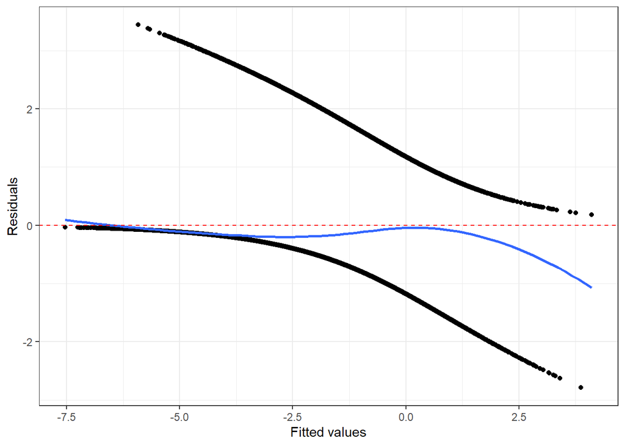

```r
augmented_df_select = augment(logistic_md_select, data = df_clean)
ggplot(data = augmented_df_select, mapping = aes(x = .fitted, y = .resid))+
geom_point() +
geom_smooth(method = "loess", formula = y ~ x, se = FALSE) +
geom_hline(yintercept = 0, linetype = "dashed", color = "red") +
labs(x = "Fitted values", y = "Residuals") +
theme_bw()
```

**Nhận xét:** Hình vẽ cho thấy xu hướng đường cong là tương đối.

$\Rightarrow$ Giả định về tính tuyến tính của mô hình là không phù hợp.

### 8.3.2 Kiểm tra tính tuyến tính từng phần

Vì chỉ có biến `bmi` là biến định lượng trong khi các biến còn lại của mô hình là định tính nên ta chỉ kiểm tra tính tuyến tính từng phần cho biến `bmi`.

```r
terms_md_select = predict(logistic_md_select, type = "terms")
residuals_md_select = residuals(logistic_md_select, type = "working")
partial_resid_bmi_select = residuals_md_select + terms_md_select[, "bmi"]
```

```r
data_part_resid_bmi_select = tibble(
  bmi = df_clean$bmi,
  terms_bmi_select = terms_md_select[, "bmi"],
  partial_resid_bmi_select = partial_resid_bmi_select)
```

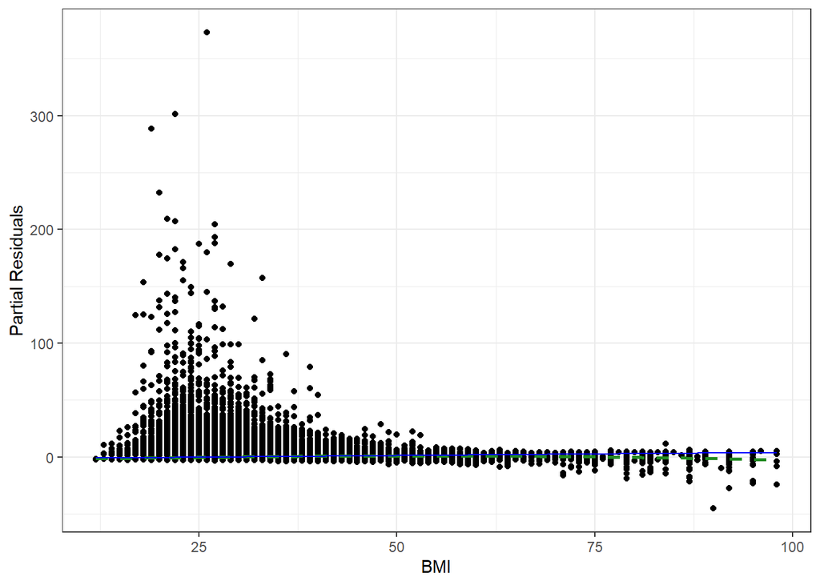

```r
ggplot(data_part_resid_bmi_select, aes(bmi, partial_resid_bmi_select)) +
  geom_point() +
  geom_smooth(method = "loess",
              se = FALSE,
              color = "forestgreen",
              linetype = "dashed") +
  geom_line(aes(x = bmi, y = terms_bmi_select), color = "blue") +
  labs(x = "BMI", y = "Partial Residuals") +
  theme_bw()
```

**Nhận xét:** Kết quả cho thấy đường thẳng tuyến tính (*màu xanh dương*) ước lượng tương đối khớp với dữ liệu.

$\Rightarrow$ Có sự tuyến tính từng phần giữa biến `bmi` và biến phụ thuộc.

Vậy thì có thể là do có nhiều biến định tính nên mô hình bị ảnh hưởng dẫn tới sự không tuyến tính trong mô hình.

### 8.3.3 Kiểm tra tính đồng nhất phương sai

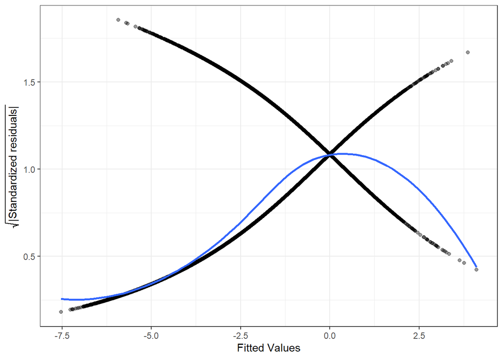

```r
ggplot(augmented_df_select, aes(.fitted, sqrt(abs(residuals(logistic_md_select, type = "deviance"))))) +
  geom_point(na.rm = TRUE, alpha = 0.4) +
  geom_smooth(method = "loess",
              na.rm = TRUE,
              se = FALSE,
              formula = y ~ x) +
  labs(x = "Fitted Values", y = expression(sqrt("|Standardized residuals|"))) +
 theme_bw()
```

**Nhận xét:**

$\Rightarrow$ Mô hình không đáp ứng được giả định về tính đồng nhất phương sai. Có thể là do có nhiều biến định tính nên mô hình bị ảnh hưởng dẫn tới sự không đồng nhất phương sai trong mô hình.

### 8.3.4 Kiểm tra điểm ngoại lai trong mô hình

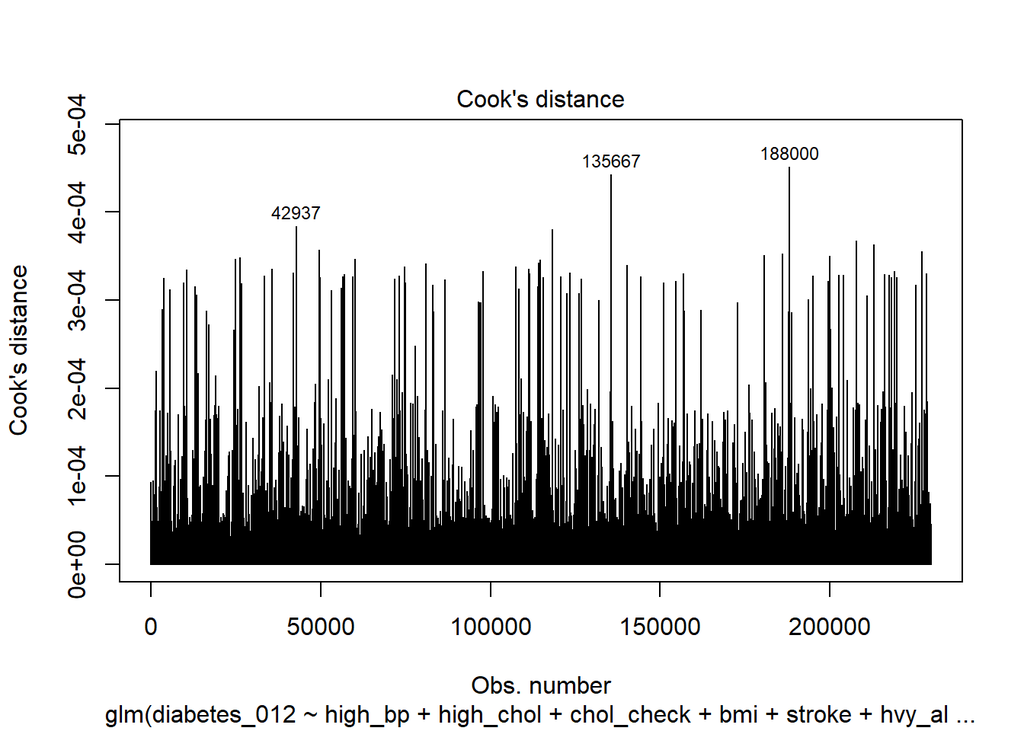

```r
plot(logistic_md_select, which = 4, id.n = 3)
```

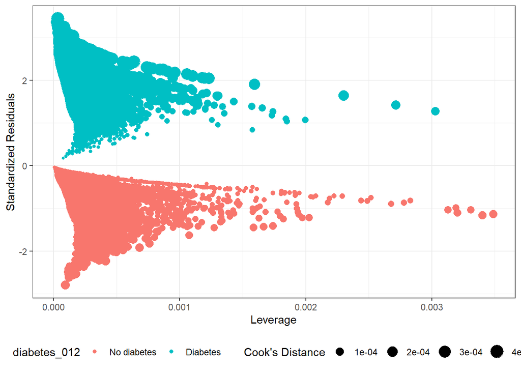

```r
ggplot(logistic_md_select, aes(.hat, .stdresid)) +
  geom_point(aes(size = .cooksd, color = diabetes_012)) +
  xlab("Leverage") +
  ylab("Standardized Residuals") +
  scale_size_continuous("Cook's Distance", range = c(1, 6)) +
  theme_bw() +
  theme(legend.position = "bottom")
```

```r
std_resid_md_select = rstandard(logistic_md_select)
hat_values_md_select = hatvalues(logistic_md_select)
cooks_D_md_select = cooks.distance(logistic_md_select)
```

```r
data_cooks_md_select = tibble(id_point = 1:nrow(df_clean),
                            rstand = std_resid_md_select, hats = hat_values_md_select,
                            cooks = cooks_D_md_select, diabetes_012 = df_clean$diabetes_012)
data_cooks_md_select |> arrange(desc(cooks))
```

| id_point | rstand | hats | cooks | diabetes_012 |
| --- | --- | --- | --- | --- |
| 188000 | 3.2357848 | 7.983264e-05 | 4.516808e-04 | Diabetes |
| 135667 | 3.0319890 | 1.489358e-04 | 4.427272e-04 | Diabetes |
| 42937 | 3.1082168 | 1.019767e-04 | 3.839205e-04 | Diabetes |
| 118313 | 3.4415767 | 3.374423e-05 | 3.805856e-04 | Diabetes |
| 207754 | 3.1774126 | 7.847877e-05 | 3.678264e-04 | Diabetes |
| 212922 | 3.2444157 | 6.235113e-05 | 3.628512e-04 | Diabetes |
| 49719 | 3.1522938 | 8.248150e-05 | 3.568512e-04 | Diabetes |
| 227062 | 2.9991208 | 1.321617e-04 | 3.554356e-04 | Diabetes |
| 186060 | 2.4339537 | 6.347303e-04 | 3.524638e-04 | Diabetes |
| 180624 | 2.8211253 | 2.205929e-04 | 3.506742e-04 | Diabetes |

[output cut: 9990 more lines]

**Nhận xét:** Vì các `Cook's Distance` của từng điểm dữ liệu trên đều nhỏ hơn 0.5 nên không có giá trị ngoại lai nào cần loại bỏ.

## 8.4 Mở rộng mô hình

Vì không thể kiểm tra tính tuyến tính cho các biến định tính trong mô hình được lựa chọn ở trên nên ta sử dụng mô hình *Cộng tính tổng quát* (Generalize Additive Moldels) hay còn gọi là GAM.

```r
md_select_gam = gam(diabetes_012 ~ high_bp +
                    high_chol +
                    chol_check +
                    s(bmi) +
                    stroke +
                    hvy_alcohol_consump +
                    gen_hlth +
                    age +
                    income +
                    sex +
                    diff_walk +
                    heart_diseaseor_attack, data = df_clean, family = binomial)
```

Kết quả tổng hợp:

```r
summary(md_select_gam)
```

```
##
## Family: binomial
## Link function: logit
##
## Formula:
## diabetes_012 ~ high_bp + high_chol + chol_check + s(bmi) + stroke +
##     hvy_alcohol_consump + gen_hlth + age + income + sex + diff_walk +
##     heart_diseaseor_attack
##
## Parametric coefficients:
##                           Estimate Std. Error z value Pr(>|z|)
## (Intercept)               -5.92946    0.12439 -47.670  < 2e-16 ***
## high_bpHigh Blood          0.61189    0.01396  43.842  < 2e-16 ***
## high_cholHigh Cholesterol  0.52951    0.01301  40.693  < 2e-16 ***
## chol_checkYes              1.19908    0.06124  19.581  < 2e-16 ***
## strokeStroke               0.13935    0.02450   5.688 1.29e-08 ***
## hvy_alcohol_consumpYes    -0.70375    0.03489 -20.169  < 2e-16 ***
## gen_hlthVery Good          0.56013    0.03038  18.439  < 2e-16 ***
## gen_hlthGood               1.12922    0.02957  38.187  < 2e-16 ***
## gen_hlthFair               1.55594    0.03165  49.162  < 2e-16 ***
## gen_hlthPoor               1.70198    0.03665  46.444  < 2e-16 ***
## age2                       0.22322    0.12720   1.755 0.079290 .
## age3                       0.42366    0.11622   3.645 0.000267 ***
## age4                       0.81610    0.11034   7.396 1.40e-13 ***
## age5                       1.02128    0.10807   9.450  < 2e-16 ***
## age6                       1.26444    0.10636  11.889  < 2e-16 ***
## age7                       1.45374    0.10526  13.811  < 2e-16 ***
## age8                       1.55269    0.10486  14.807  < 2e-16 ***
## age9                       1.77089    0.10461  16.928  < 2e-16 ***
## age10                      1.92899    0.10457  18.446  < 2e-16 ***
## age11                      1.99557    0.10492  19.020  < 2e-16 ***
## age12                      1.94519    0.10557  18.425  < 2e-16 ***
## age13                      1.82349    0.10566  17.258  < 2e-16 ***
## income2                   -0.05018    0.03425  -1.465 0.142910
## income3                   -0.10364    0.03293  -3.148 0.001647 **
## income4                   -0.15056    0.03212  -4.688 2.76e-06 ***
## income5                   -0.22731    0.03148  -7.220 5.19e-13 ***
## income6                   -0.31350    0.03072 -10.204  < 2e-16 ***
## income7                   -0.34586    0.03077 -11.239  < 2e-16 ***
## income8                   -0.44280    0.02989 -14.816  < 2e-16 ***
## sexMale                    0.22666    0.01280  17.709  < 2e-16 ***
## diff_walkYes               0.08699    0.01572   5.535 3.12e-08 ***
## heart_diseaseor_attackYes  0.21459    0.01737  12.352  < 2e-16 ***
## ---
## Signif. codes:  0 '***' 0.001 '**' 0.01 '*' 0.05 '.' 0.1 ' ' 1
##
## Approximate significance of smooth terms:
##          edf Ref.df Chi.sq p-value
## s(bmi) 6.913  7.727   5427  <2e-16 ***
## ---
## Signif. codes:  0 '***' 0.001 '**' 0.01 '*' 0.05 '.' 0.1 ' ' 1
##
## R-sq.(adj) =  0.187   Deviance explained =   20%
## UBRE = -0.26308  Scale est. = 1         n = 229781
```

Một số nhận xét:

- Hệ số dương của biến `high_bpHigh Blood` cho thấy những người bị huyết áp cao có khả năng mắc bệnh tiểu đường cao hơn so với những người không bị huyết áp cao. Việc tăng một đơn vị của biến `high_bp` sẽ làm tăng tỷ lệ mắc bệnh tiểu đường lên $exp(0.61189) \approx 1.843$ lần.
- Hệ số dương của biến `high_cholHigh Cholesterol` cho thấy những người bị cholesterol cao có khả năng mắc bệnh tiểu đường cao hơn so với những người không bị cholesterol cao.
- Hệ số âm của biến `hvy_alcohol_consumpYes` cho thấy rằng người tiêu thụ rượu nặng có nguy cơ mắc bệnh tiểu đường thấp hơn so với người không tiêu thụ rượu nặng. Tuy nhiên, đây không phải là kết luận chắc chắn, vì tiêu thụ rượu nặng quá mức cũng có thể gây ảnh hưởng tiêu cực đến sức khỏe tổng thể.
- Hệ số dương của các mức biến `gen_hlth` (`Very Good`, `Good`, `Fair`, `Poor`) cho thấy rằng nguy cơ mắc bệnh tiểu đường tăng dần theo sự giảm sút của sức khỏe. Những người có sức khỏe “Fair” hoặc “Poor” có nguy cơ mắc bệnh tiểu đường cao hơn so với những người có sức khỏe “Excellent”.
- Với hệ số âm của các mức biến `income` (từ `income2` đến `income8`), ta nhận thấy rằng người có thu nhập càng cao thì nguy cơ mắc bệnh tiểu đường càng thấp. Điều này có thể do khả năng tiếp cận dịch vụ y tế tốt hơn hoặc duy trì lối sống lành mạnh hơn.
- Hệ số dương của các mức biến `age` (từ `age2` đến `age13`) cho thấy rằng nguy cơ mắc bệnh tiểu đường tăng dần theo độ tuổi. Cụ thể, người ở nhóm tuổi cao nhất (`age13`) có nguy cơ mắc bệnh tiểu đường cao hơn đáng kể so với nhóm tuổi trẻ nhất.
- Hệ số dương của biến `sexMale` cho thấy rằng nam giới có nguy cơ mắc bệnh tiểu đường cao hơn so với nữ giới. Cụ thể, việc tăng một đơn vị của biến này sẽ làm tăng tỷ lệ mắc bệnh tiểu đường lên $exp(0.22666) \approx 1.254$ lần.
- Hệ số dương của biến `diff_walkYes` chỉ ra rằng người gặp khó khăn khi leo cầu thang có nguy cơ mắc bệnh tiểu đường cao hơn người không gặp khó khăn.
- Hệ số dương của biến `heart_diseaseor_attackYes` cho thấy rằng người từng mắc bệnh tim hoặc đau tim có nguy cơ mắc bệnh tiểu đường cao hơn. Cụ thể, việc tăng một đơn vị của biến này sẽ làm tăng tỷ lệ mắc bệnh tiểu đường lên $exp(0.21459) \approx 1.239$ lần.

Ta sẽ sử dụng mô hình này để phân loại dữ liệu về 5 người ở bước **Lựa chọn mô hình** phía trên thành hai nhóm là: `Không mắc bệnh tiểu đường` và `Mắc bệnh tiểu đường` bằng cách so sánh xác suất ở ngưỡng $c = 0.5$.

```r
predict_prob = predict(md_select_gam, newdata = new_data_1, type = "response")
ifelse(predict_prob > 0.5, "Diabetes", "No Diabetes")
```

```
##             1             2             3             4             5
##    "Diabetes" "No Diabetes" "No Diabetes" "No Diabetes" "No Diabetes"
```

1. Xác định thặng dư từng phần

```r
terms_md_select_gam = predict(md_select_gam, type = "terms")
```

```r
partial_resid_md_select_gam = residuals(md_select_gam, type = "working") +
  terms_md_select_gam
```

2. Tạo bảng dữ liệu có thông tin cần thiết

```r
terms_md_select_gam = predict(md_select_gam, type = "terms")
partial_resid_md_select_gam = residuals(md_select_gam, type = "working") +
  terms_md_select_gam

data_part_resid_bmi_gam = tibble(
  bmi = df_clean$bmi,
  terms_bmi_gam = terms_md_select_gam[, "s(bmi)"],
  partial_resid_bmi = partial_resid_md_select_gam[, "s(bmi)"]
)
```

3. Vẽ biểu đồ để kiểm tra tính tuyến tính của `bmi` và biến phụ thuộc

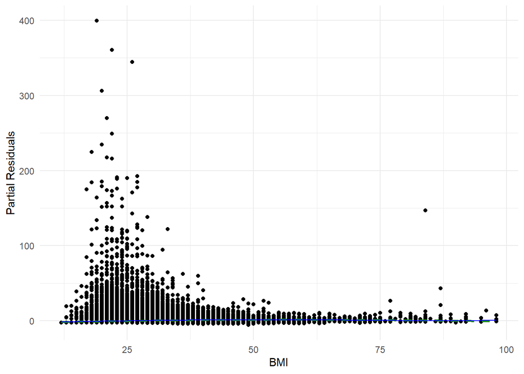

```r
ggplot(data_part_resid_bmi_gam, aes(x = bmi, y = partial_resid_bmi)) +
  geom_point() +
  geom_smooth(method = "loess",
              se = FALSE,
              color =  "forestgreen",
              linetype = "dashed") +
  geom_line(aes(x = bmi, y = terms_bmi_gam), color = "blue") +
  labs(x = "BMI", y = "Partial Residuals") +
  theme_minimal()
```

**Nhận xét:** Đường thẳng tuyến tính (màu xanh dương) trùng với đường thẳng xu hướng của dữ liệu (màu xanh lá cây).

$\Rightarrow$ Giả định về tính tuyến tính của `bmi` là phù hợp.

# 9. Đánh giá mô hình

## 9.1 Chia dữ liệu thành 2 tập huấn luyện và kiểm tra

- Tập huấn luyện **(train)**: 70% dữ liệu
- Tập kiểm tra **(test)**: 30% dữ liệu

```r
set.seed(123)
n = nrow(df_clean)
train.index = sample(1:n, 0.7 * n, replace = FALSE)
train_df = df_clean[train.index, ]
test_df = df_clean[-train.index, ]
```

## 9.2 Hàm tính các giá trị đánh giá mô hình

```r
evaluate_model = function(x)
{
    cc = sum(diag(x))
    sc = sum(x)
    pp = colSums(x)
    tt = rowSums(x)

    prec = diag(x) / pp
    recall = diag(x) / tt
    macro_prec = mean(prec)
    macro_recall = mean(recall)
    macro_f1 = 2 * macro_prec * macro_recall / (1 / macro_prec + 1 / macro_recall)
    acc = cc/sc

    kap = (as.numeric(cc) * as.numeric(sc) - sum(tt * pp)) / (as.numeric(sc) ^ 2 - sum(tt * pp))

    return(list(Accuaracy = acc,
                Precision = prec,
                Recall = recall,
                Macro_F1 = macro_f1,
                Kappa = kap))
}
```

## 9.3 Xử lý dữ liệu mất cân bằng

Ta thực hiện xử lý mất cân bằng dữ liệu trên tập huấn luyện.

```r
table(train_df$diabetes_012)
```

```
##
## No diabetes    Diabetes
##      132995       27851
```

- **Under-sampling**

```r
set.seed(123)

under_sampling = function(data, class)
{
    new_data = data
    class_fact = as.factor(data[[class]])
    data_split = split(data, class_fact)
    n_class = sapply(data_split, FUN = nrow)
    min_class = min(n_class)
    max_class = max(n_class)

    id_max_class = which.max(n_class)
    id_min_class = which.min(n_class)

    id_max = sample(1:max_class, size = min_class, replace =  FALSE)
    new_data_max = data_split[[id_max_class]][id_max, ]
    new_data = rbind(data_split[[id_min_class]], new_data_max)
    return (new_data)
}

train_df_under = under_sampling(train_df, "diabetes_012")

table(train_df_under$diabetes_012)
```

```
##
## No diabetes    Diabetes
##       27851       27851
```

- **SMOTE**

```r
library(themis)
set.seed(123)
train_df_smote = smotenc(df = train_df,
                            var = "diabetes_012",
                            k = 5,
                            over_ratio = 1)
```

```r
table(train_df_smote$diabetes_012)
```

```
##
## No diabetes    Diabetes
##      132995      132995
```

## 9.4 Đánh giá mô hình

### 9.4.1 Xây dựng mô hình với tập huấn luyện

Xây dựng mô hình với tập huấn luyện sau khi thực hiện 2 phương pháp *Under-sampling* và *SMOTE*.

- **Under-sampling**

```r
logit_2_under = glm(diabetes_012 ~ high_bp +
                    high_chol +
                    chol_check +
                    bmi +
                    stroke +
                    hvy_alcohol_consump +
                    gen_hlth +
                    age +
                    income +
                    sex +
                    diff_walk +
                    heart_diseaseor_attack,
              data = train_df_under, family = "binomial")
summary(logit_2_under)
```

```
##
## Call:
## glm(formula = diabetes_012 ~ high_bp + high_chol + chol_check +
##     bmi + stroke + hvy_alcohol_consump + gen_hlth + age + income +
##     sex + diff_walk + heart_diseaseor_attack, family = "binomial",
##     data = train_df_under)
##
## Coefficients:
##                           Estimate Std. Error z value Pr(>|z|)
## (Intercept)               -6.32364    0.16871 -37.481  < 2e-16 ***
## high_bpHigh Blood          0.61856    0.02164  28.588  < 2e-16 ***
## high_cholHigh Cholesterol  0.52857    0.02072  25.513  < 2e-16 ***
## chol_checkYes              1.30357    0.08580  15.193  < 2e-16 ***
## bmi                        0.06645    0.00168  39.553  < 2e-16 ***
## strokeStroke               0.12549    0.04350   2.885 0.003918 **
## hvy_alcohol_consumpYes    -0.73093    0.05094 -14.349  < 2e-16 ***
## gen_hlthVery Good          0.58382    0.04132  14.129  < 2e-16 ***
## gen_hlthGood               1.17637    0.04060  28.975  < 2e-16 ***
## gen_hlthFair               1.59484    0.04545  35.091  < 2e-16 ***
## gen_hlthPoor               1.73633    0.05738  30.260  < 2e-16 ***
## age2                       0.24088    0.16108   1.495 0.134812
## age3                       0.27558    0.14795   1.863 0.062510 .
## age4                       0.76942    0.13991   5.499 3.81e-08 ***
## age5                       0.92107    0.13685   6.731 1.69e-11 ***
## age6                       1.16673    0.13428   8.689  < 2e-16 ***
## age7                       1.40932    0.13229  10.653  < 2e-16 ***
## age8                       1.50844    0.13161  11.462  < 2e-16 ***
## age9                       1.68500    0.13124  12.839  < 2e-16 ***
## age10                      1.85622    0.13120  14.148  < 2e-16 ***
## age11                      1.95196    0.13196  14.792  < 2e-16 ***
## age12                      1.84592    0.13324  13.854  < 2e-16 ***
## age13                      1.73581    0.13324  13.028  < 2e-16 ***
## income2                   -0.03275    0.06014  -0.545 0.586011
## income3                   -0.13728    0.05691  -2.412 0.015866 *
## income4                   -0.18429    0.05525  -3.335 0.000852 ***
## income5                   -0.22429    0.05385  -4.165 3.11e-05 ***
## income6                   -0.33091    0.05220  -6.339 2.31e-10 ***
## income7                   -0.38076    0.05195  -7.330 2.31e-13 ***
## income8                   -0.49329    0.05035  -9.796  < 2e-16 ***
## sexMale                    0.28549    0.02063  13.841  < 2e-16 ***
## diff_walkYes               0.12856    0.02694   4.772 1.82e-06 ***
## heart_diseaseor_attackYes  0.24288    0.03085   7.874 3.45e-15 ***
## ---
## Signif. codes:  0 '***' 0.001 '**' 0.01 '*' 0.05 '.' 0.1 ' ' 1
##
## (Dispersion parameter for binomial family taken to be 1)
##
##     Null deviance: 77219  on 55701  degrees of freedom
## Residual deviance: 59840  on 55669  degrees of freedom
## AIC: 59906
##
## Number of Fisher Scoring iterations: 5
```

- **SMOTE**

```r
logit_2_smote = glm(diabetes_012 ~ high_bp +
                    high_chol +
                    chol_check +
                    bmi +
                    stroke +
                    hvy_alcohol_consump +
                    gen_hlth +
                    age +
                    income +
                    sex +
                    diff_walk +
                    heart_diseaseor_attack,
              data = train_df_smote, family = "binomial")
summary(logit_2_smote)
```

```
##
## Call:
## glm(formula = diabetes_012 ~ high_bp + high_chol + chol_check +
##     bmi + stroke + hvy_alcohol_consump + gen_hlth + age + income +
##     sex + diff_walk + heart_diseaseor_attack, family = "binomial",
##     data = train_df_smote)
##
## Coefficients:
##                             Estimate Std. Error z value Pr(>|z|)
## (Intercept)               -9.0237494  0.1152282 -78.312  < 2e-16 ***
## high_bpHigh Blood          0.6494501  0.0102162  63.571  < 2e-16 ***
## high_cholHigh Cholesterol  0.5311677  0.0097169  54.664  < 2e-16 ***
## chol_checkYes              2.4563582  0.0652755  37.631  < 2e-16 ***
## bmi                        0.0716242  0.0008329  85.990  < 2e-16 ***
## strokeStroke              -0.2614840  0.0215612 -12.128  < 2e-16 ***
## hvy_alcohol_consumpYes    -1.6306329  0.0318433 -51.208  < 2e-16 ***
## gen_hlthVery Good          0.9253951  0.0213900  43.263  < 2e-16 ***
## gen_hlthGood               1.5886476  0.0211236  75.207  < 2e-16 ***
## gen_hlthFair               2.0164356  0.0234584  85.958  < 2e-16 ***
## gen_hlthPoor               2.1398415  0.0288640  74.135  < 2e-16 ***
## age2                       0.4293251  0.1058546   4.056 5.00e-05 ***
## age3                       0.5889175  0.0977711   6.023 1.71e-09 ***
## age4                       1.3044329  0.0924751  14.106  < 2e-16 ***
## age5                       1.5028866  0.0910329  16.509  < 2e-16 ***
## age6                       1.8642200  0.0898001  20.760  < 2e-16 ***
## age7                       2.2666766  0.0889785  25.474  < 2e-16 ***
## age8                       2.4178030  0.0887256  27.250  < 2e-16 ***
## age9                       2.6840585  0.0885980  30.295  < 2e-16 ***
## age10                      2.8954527  0.0885988  32.681  < 2e-16 ***
## age11                      2.9446420  0.0888523  33.141  < 2e-16 ***
## age12                      2.8589226  0.0893180  32.008  < 2e-16 ***
## age13                      2.7295987  0.0893119  30.563  < 2e-16 ***
## income2                   -0.0373888  0.0288812  -1.295 0.195468
## income3                   -0.0689578  0.0275368  -2.504 0.012273 *
## income4                   -0.0695078  0.0266611  -2.607 0.009132 **
## income5                   -0.1189334  0.0260086  -4.573 4.81e-06 ***
## income6                   -0.1650268  0.0253131  -6.519 7.06e-11 ***
## income7                   -0.1622009  0.0252460  -6.425 1.32e-10 ***
## income8                   -0.1796382  0.0245478  -7.318 2.52e-13 ***
## sexMale                    0.2639824  0.0097167  27.168  < 2e-16 ***
## diff_walkYes               0.0071611  0.0129396   0.553 0.579974
## heart_diseaseor_attackYes  0.0560027  0.0146545   3.822 0.000133 ***
## ---
## Signif. codes:  0 '***' 0.001 '**' 0.01 '*' 0.05 '.' 0.1 ' ' 1
##
## (Dispersion parameter for binomial family taken to be 1)
##
##     Null deviance: 368740  on 265989  degrees of freedom
## Residual deviance: 274397  on 265957  degrees of freedom
## AIC: 274463
##
## Number of Fisher Scoring iterations: 6
```

### 9.4.2 Dự đoán trên tập kiểm tra

- **Under-sampling**

```r
logit_2_under_pred = predict(logit_2_under, test_df, type = "response")

logit_2_under_pred_class = factor(
  ifelse(logit_2_under_pred < 0.5, "No diabetes", "Diabetes"),
  levels = c("No diabetes", "Diabetes")
)

conf_matrix_logit_2_under = table(test_df$diabetes_012, logit_2_under_pred_class)

print(conf_matrix_logit_2_under)
```

```
##              logit_2_under_pred_class
##               No diabetes Diabetes
##   No diabetes       40284    16776
##   Diabetes           2916     8959
```

Kết quả của các chỉ số:

```r
evaluate_model(conf_matrix_logit_2_under)
```

```
## $Accuaracy
## [1] 0.7143396
##
## $Precision
## No diabetes    Diabetes
##   0.9325000   0.3481251
##
## $Recall
## No diabetes    Diabetes
##   0.7059937   0.7544421
##
## $Macro_F1
## [1] 0.3190291
##
## $Kappa
## [1] 0.314908
```

Như vậy, ta có được các nhận định sau:

1. **Accuracy**: 71.4%
- Mặc dù đây là một chỉ số phổ biến, nhưng khi dữ liệu đã được cân bằng, độ chính xác không còn là tiêu chí đáng tin cậy để đánh giá mô hình.
- Mức 71.4% cho thấy mô hình đạt độ chính xác khá ổn, nhưng cần kết hợp với Precision, Recall, và F1-Score để đánh giá toàn diện.
2. **Precision**
- `No diabetes`: 93.25%

$\Rightarrow$ Mô hình dự đoán lớp `No diabetes` khá chính xác. Trong số các mẫu được dự đoán là `No diabetes` có đến 93.25% là đúng.

- `Diabetes`: 34.81%

$\Rightarrow$ Với lớp `Diabetes` Precision thấp cho thấy mô hình có nhiều dự đoán sai dương tính **(false positives)** tức là nhiều mẫu bị dự đoán nhầm thành `Diabetes`.

3. **Recall (Sensitivity)**
- `No diabetes`: 70.6%

$\Rightarrow$ Mô hình nhận diện được phần lớn các mẫu thuộc lớp `No diabetes` nhưng vẫn bỏ sót khoảng 29.4% (**False Negative**).

- `Diabetes`: 75.44%

$\Rightarrow$ Mô hình nhận diện tốt hơn các mẫu thuộc lớp `Diabetes` với tỷ lệ bỏ sót là 24.56%

4. **Macro F1-Score**: 31.90%
- Giá trị thấp (31.9%) cho thấy hiệu suất của mô hình với lớp `Diabetes` chưa đạt được kỳ vọng.
5. **Kappa**: 31.49%

Hệ số Kappa thấp phản ánh rằng mô hình chỉ hiệu quả hơn một chút so với việc đoán ngẫu nhiên.

- **SMOTE**

```r
logit_2_smote_pred = predict(logit_2_smote, test_df, type = "response")
logit_2_smote_pred_class = ifelse(logit_2_smote_pred >= 0.5, "Diabetes", "No diabetes")
logit_2_smote_pred_class = factor(logit_2_smote_pred_class, levels = c("No diabetes", "Diabetes"))

conf_matrix_logit_2_smote = table(test_df$diabetes_012, logit_2_smote_pred_class)

print(conf_matrix_logit_2_smote)
```

```
##              logit_2_smote_pred_class
##               No diabetes Diabetes
##   No diabetes       40116    16944
##   Diabetes           2954     8921
```

Kết quả của các chỉ số

```r
evaluate_model(conf_matrix_logit_2_smote)
```

```
## $Accuaracy
## [1] 0.7113513
##
## $Precision
## No diabetes    Diabetes
##   0.9314140   0.3449062
##
## $Recall
## No diabetes    Diabetes
##   0.7030494   0.7512421
##
## $Macro_F1
## [1] 0.3154295
##
## $Kappa
## [1] 0.3097874
```

1. **Accuracy**: 71.14%

Mức độ chính xác tổng thể của mô hình, nhưng không phản ánh toàn diện hiệu suất trong bài toán mất cân bằng.

2. **Precision**:
- `No diabetes`: 93.14$\%$ (dự đoán rất chính xác).
- `Diabetes`: 34.49$\%$ (dự đoán còn nhiều nhầm lẫn).
3. **Recall**:
- `No diabetes`: 70.30$\%$ (phát hiện được phần lớn các trường hợp “No diabetes”).
- `Diabetes`: 75.12$\%$ (ít bỏ sót các trường hợp mắc bệnh).
4. **Macro F1-Score**: 31.54%

Hiệu suất tổng thể của mô hình còn thấp.

5. **Kappa**: 30.98%

Dự đoán của mô hình chỉ tốt hơn ngẫu nhiên một chút, mặc dù đã áp dụng cân bằng dữ liệu bằng SMOTE.

### 9.4.3 Đánh giá dựa trên ROC và AUC

- **Under-sampling**

```r
prob_pred_dt_2_under = predict(logit_2_under, type = "response", newdata = test_df)
out_roc_2_under = roc(test_df$diabetes_012 ~ prob_pred_dt_2_under)
out_roc_2_under$auc
```

```
## Area under the curve: 0.8058
```

- Giá trị AUC đạt 80.58% cho thấy mô hình Logistic Regression sau khi áp dụng under-sampling có khả năng phân biệt khá tốt giữa hai nhóm `Diabetes` và `No diabetes`.
- AUC nằm trong khoảng từ 0.8 đến 0.9, được xem là tốt. Điều này phản ánh rằng mô hình có khả năng phân loại tốt trong việc dự đoán xác suất mắc bệnh.

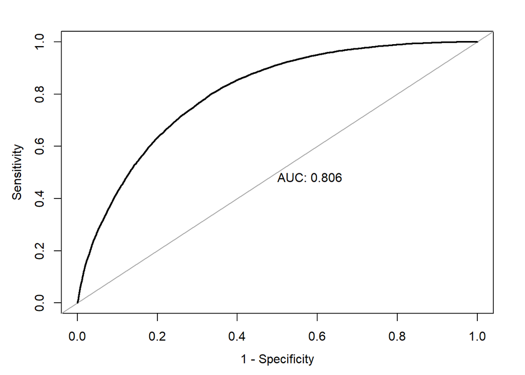

```r
plot(out_roc_2_under, legacy.axes = TRUE, asp = 0, print.auc = TRUE)
```

Biểu đồ trên cho ta thấy rằng:

1. Một AUC cao như 0.8058 cho thấy mô hình có thể cân bằng tốt giữa *Sensitivity* và *Specificity* ở một số ngưỡng tối ưu.
2. Với AUC = 0.8058, mô hình có khả năng dự đoán tốt hơn ngẫu nhiên (AUC = 0.5) một cách đáng kể.
- **SMOTE**

```r
prob_pred_dt_2_smote = predict(logit_2_smote, type = "response", newdata = test_df)
out_roc_2_smote = roc(test_df$diabetes_012 ~ prob_pred_dt_2_smote)
out_roc_2_smote$auc
```

```
## Area under the curve: 0.8003
```

- Giá trị AUC đạt 80.03% cho thấy mô hình Logistic Regression sau khi áp dụng SMOTE có khả năng phân biệt khá tốt giữa hai nhóm `Diabetes` và `No diabetes`.
- AUC nằm trong khoảng từ 0.8 đến 0.9, được xem là tốt. Điều này phản ánh rằng mô hình có khả năng phân loại tốt trong việc dự đoán xác suất mắc bệnh.

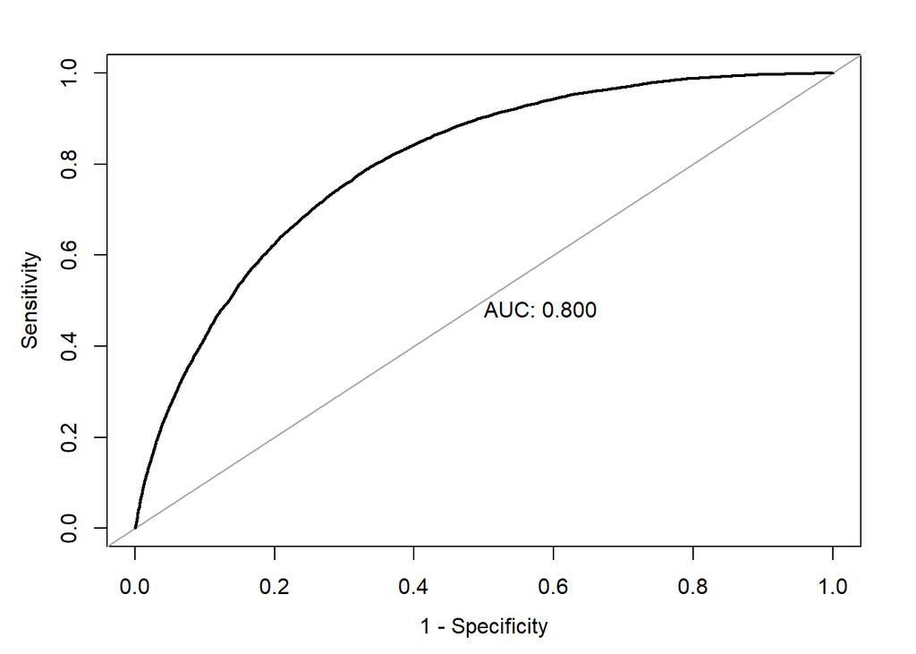

```r
plot(out_roc_2_smote, legacy.axes = TRUE, asp = 0, print.auc = TRUE)
```

Qua biểu đồ ta thấy được:

1. Một AUC cao như 0.8003 cho thấy mô hình có thể cân bằng tốt giữa *Sensitivity* và *Specificity* ở một số ngưỡng tối ưu.
2. Với AUC = 0.8003, mô hình có khả năng dự đoán tốt hơn ngẫu nhiên (AUC = 0.5) một cách đáng kể.

# 10. Kết luận